# What sets European regions apart?

# Project

[figure not shown]

The project tries to understand what are the main differences across European Union’s NUTS-3 level regions applying statistical and machine learning techniques to socio-economic and environmental data in order to:

1. Classify each NUTS-3 region into its continental subregion (Eastern, Western, Northern or Southern Europe)
2. Predict NUTS-3 regions’ GDP

# Loading libraries

```r
rm(list = ls())
library(MASS)
library(tidyverse)
library(httr2)
library(DataExplorer)
library(explore)
library(mice)
library(caret)
library(nnet)
library(pdp)
library(rpart.plot)
library(gbm)
library(olsrr)
library(fastDummies)
```

# Loading data

All the data used is at the third regional level (corresponding to the EU’s NUTS-3 level), and it is obtained from [OECD](https://data-explorer.oecd.org/) databases which seemed the source with the most data available for level-3 regions.

```r
# data <- request("https://sdmx.oecd.org/public/rest/data/OECD.CFE.EDS,DSD_REG_DEMO@DF_DEMO,2.0/A.TL3...LAND_AREA+POP...?startPeriod=2010&endPeriod=2022&dimensionAtObservation=AllDimensions&format=csvfilewithlabels") |> req_perform()
# writeBin(resp_body_raw(data), "data/population.csv")
population <- read_csv("data/population.csv", show_col_types = FALSE)

# data <- request("https://sdmx.oecd.org/public/rest/data/OECD.CFE.EDS,DSD_REG_DEMO@DF_DEMO,2.0/A.TL3...DEPEND_RATIO+FERT_RATIO...?startPeriod=2010&endPeriod=2022&dimensionAtObservation=AllDimensions&format=csvfilewithlabels") |> req_perform()
# writeBin(resp_body_raw(data), "data/demographic.csv")
demographic <- read_csv("data/demographic.csv", show_col_types = FALSE)

# data <- request("https://sdmx.oecd.org/public/rest/data/OECD.CFE.EDS,DSD_REG_DEMO@DF_DEMO,2.0/A.TL3...NETMIG+OUTMIG+INMIG+NETMOB+OUTMOB+INMOB...?startPeriod=2010&endPeriod=2022&dimensionAtObservation=AllDimensions&format=csvfilewithlabels") |> req_perform()
# writeBin(resp_body_raw(data), "data/migration.csv")
migration <- read_csv("data/migration.csv", show_col_types = FALSE)

# data <- request("https://sdmx.oecd.org/public/rest/data/OECD.CFE.EDS,DSD_REG_DEMO@DF_DEMO,2.0/A.TL3...MORT_ICDV_CRUDE_RATIO+MORT_ICDI_CRUDE_RATIO+MORT_ICDJ_CRUDE_RATIO+MORT_INFANT+MORT_STANDARD_RATIO+LFEXP...?startPeriod=2010&endPeriod=2022&dimensionAtObservation=AllDimensions&format=csvfilewithlabels") |> req_perform()
# writeBin(resp_body_raw(data), "data/mortality.csv")
mortality <- read_csv("data/mortality.csv", show_col_types = FALSE)

# data <- request("https://sdmx.oecd.org/public/rest/data/OECD.CFE.EDS,DSD_REG_SOC@DF_SOC,2.2/A.TL3...MORT_ICDV_CRUDE_RATIO+VEH_THEFT...?startPeriod=2010&endPeriod=2022&dimensionAtObservation=AllDimensions&format=csvfilewithlabels") |> req_perform()
# writeBin(resp_body_raw(data), "data/safety.csv")
safety <- read_csv("data/safety.csv", show_col_types = FALSE)

# data <- request("https://sdmx.oecd.org/public/rest/data/OECD.CFE.EDS,DSD_REG_SOC@DF_SOC,2.2/A.TL3...VEH_STOCK_ELECTRIC...?startPeriod=2010&endPeriod=2022&dimensionAtObservation=AllDimensions&format=csvfilewithlabels") |> req_perform()
# writeBin(resp_body_raw(data), "data/electric_cars.csv")
electric_cars <- read_csv("data/electric_cars.csv", show_col_types = FALSE)

# data <- request("https://sdmx.oecd.org/public/rest/data/OECD.CFE.EDS,DSD_REG_SOC@DF_SOC,2.2/A.TL3...BB_ACC...?startPeriod=2010&endPeriod=2022&dimensionAtObservation=AllDimensions&format=csvfilewithlabels") |> req_perform()
# writeBin(resp_body_raw(data), "data/internet_access.csv")
internet_access <- read_csv("data/internet_access.csv", show_col_types = FALSE)

# data <- request("https://sdmx.oecd.org/public/rest/data/OECD.CFE.EDS,DSD_REG_ECO@DF_ECO,2.0/A.TL3...GDP..Q.USD_PPP_PS?startPeriod=2010&endPeriod=2022&dimensionAtObservation=AllDimensions&format=csvfilewithlabels") |> req_perform()
# writeBin(resp_body_raw(data), "data/gdp.csv")
gdp <- read_csv("data/gdp.csv", show_col_types = FALSE)

# data <- request("https://sdmx.oecd.org/public/rest/data/OECD.CFE.EDS,DSD_REG_ECO@DF_ECO,2.0/A.TL3...B5N..Q.USD_PPP_PS?startPeriod=2010&endPeriod=2022&dimensionAtObservation=AllDimensions&format=csvfilewithlabels") |> req_perform()
# writeBin(resp_body_raw(data), "data/income.csv")
income <- read_csv("data/income.csv", show_col_types = FALSE)

# data <- request("https://sdmx.oecd.org/public/rest/data/OECD.CFE.EDS,DSD_REG_ECO@DF_ECO,2.0/A.TL3...LAB_PROD._T.Q.USD_PPP_WR?startPeriod=2010&endPeriod=2022&dimensionAtObservation=AllDimensions&format=csvfilewithlabels") |> req_perform()
# writeBin(resp_body_raw(data), "data/labour_productivity.csv")
labour_productivity <- read_csv("data/labour_productivity.csv", show_col_types = FALSE)

# data <- request("https://sdmx.oecd.org/public/rest/data/OECD.CFE.EDS,DSD_REG_LABOUR@DF_LAB,2.0/A.TL3...EMP_RATIO.Y15T64._T.PT_POP_SUB?startPeriod=2010&endPeriod=2022&dimensionAtObservation=AllDimensions&format=csvfilewithlabels") |> req_perform()
# writeBin(resp_body_raw(data), "data/employment.csv")
employment <- read_csv("data/employment.csv", show_col_types = FALSE)

# data <- request("https://sdmx.oecd.org/public/rest/data/OECD.CFE.EDS,DSD_REG_LABOUR@DF_LAB,2.0/A.TL3...UNE_RATE.Y15T64._T.PT_LF_SUB?startPeriod=2010&endPeriod=2022&dimensionAtObservation=AllDimensions&format=csvfilewithlabels") |> req_perform()
# writeBin(resp_body_raw(data), "data/unemployment.csv")
unemployment <- read_csv("data/unemployment.csv", show_col_types = FALSE)

# data <- request("https://sdmx.oecd.org/public/rest/data/OECD.CFE.EDS,DSD_REG_LABOUR@DF_LAB,2.0/A.TL3...LF_RATE_SEXDIF.Y15T64._T.PD?startPeriod=2010&endPeriod=2022&dimensionAtObservation=AllDimensions&format=csvfilewithlabels") |> req_perform()
# writeBin(resp_body_raw(data), "data/gender_diff_labour_force_participation.csv")
gender_diff_labour_force_participation <- read_csv("data/gender_diff_labour_force_participation.csv", show_col_types = FALSE)

# data <- request("https://sdmx.oecd.org/public/rest/data/OECD.CFE.EDS,DSD_REG_CLIM@DF_CLIM,1.0/A.TL3...RF_LAND_EXP+CF_LAND_EXP.Y_20...?startPeriod=2010&endPeriod=2022&dimensionAtObservation=AllDimensions&format=csvfilewithlabels") |> req_perform()
# writeBin(resp_body_raw(data), "data/floodings.csv")
floodings <- read_csv("data/floodings.csv", show_col_types = FALSE)

# data <- request("https://sdmx.oecd.org/public/rest/data/OECD.CFE.EDS,DSD_REG_CLIM@DF_CLIM,1.0/A.TL3...FIRE_LAND_EXP....PT_LAR?startPeriod=2010&endPeriod=2022&dimensionAtObservation=AllDimensions&format=csvfilewithlabels") |> req_perform()
# writeBin(resp_body_raw(data), "data/wildfires.csv")
wildfires <- read_csv("data/wildfires.csv", show_col_types = FALSE)

# data <- request("https://sdmx.oecd.org/public/rest/data/OECD.CFE.EDS,DSD_REG_HEALTH@DF_CARE,2.0/A.TL3...HB...10P3HB?startPeriod=2010&endPeriod=2022&dimensionAtObservation=AllDimensions&format=csvfilewithlabels") |> req_perform()
# writeBin(resp_body_raw(data), "data/hospital_beds.csv")
hospital_beds <- read_csv("data/hospital_beds.csv", show_col_types = FALSE)

# data <- request("https://sdmx.oecd.org/public/rest/data/OECD.CFE.EDS,DSD_REG_HEALTH@DF_RISK,2.0/A.TL3...PM25_POP_EXP+OBESITY...?startPeriod=2010&endPeriod=2022&dimensionAtObservation=AllDimensions&format=csvfilewithlabels") |> req_perform()
# writeBin(resp_body_raw(data), "data/health_risks.csv")
health_risks <- read_csv("data/health_risks.csv", show_col_types = FALSE)

# data <- request("https://sdmx.oecd.org/public/rest/data/OECD.CFE.EDS,DSD_REG_PAT@DF_PAT,1.0/A.TL3....APPLICATION.PAT.._T.10P6HB?startPeriod=2010&endPeriod=2022&dimensionAtObservation=AllDimensions&format=csvfilewithlabels") |> req_perform()
# writeBin(resp_body_raw(data), "data/patents.csv")
patents <- read_csv("data/patents.csv", show_col_types = FALSE)
```

The data has been obtained through talking directly to the OECD API and the written over .csv files to avoid having to recall the API each time. The code with the queries to the API and the writing of the .csv files have been commented, but they remain available for any future update or for reproducibility.

# Data cleaning

First cleaning of the variables (selecting the relevant age, sex groups and/or relevant units of measure):

```r
# Population and population density
population <- population |>
  select(REF_AREA, `Reference area`, Measure, Age, Sex, `Unit of measure`,
         TIME_PERIOD, OBS_VALUE, COUNTRY, Country)
tot_population <- population |>
  filter(Measure=="Population") |>
  filter(Age=="Total") |>
  filter(Sex=="Total") |>
  filter(`Unit of measure`=="Persons")
pop_density <- population |>
  filter(Measure=="Population") |>
  filter(Age=="Total") |>
  filter(Sex=="Total") |>
  filter(`Unit of measure`=="Persons per square kilometer")

# Fertility rate and age dependency
demographic <- demographic |>
  select(REF_AREA, `Reference area`, Measure, Age, Sex, `Unit of measure`,
         TIME_PERIOD, OBS_VALUE, COUNTRY, Country)
fertility_rate <- demographic |>
  filter(Measure=="Fertility rate") |>
  filter(Age == "Total")
old_dependency_ratio <- demographic |>
  filter(Measure=="Dependency ratio") |>
  filter(Age == "65 years or over") |>
  filter(`Unit of measure` == "Percentage of population aged 15-64 years")

# Net national and international migration
migration <- migration |>
  select(REF_AREA, `Reference area`, Measure, Age, Sex, `Unit of measure`,
         TIME_PERIOD, OBS_VALUE, COUNTRY, Country) |>
  filter(Sex == "Total") |>
  filter(Measure %in% c("Net inter-regional mobility (inflows minus outflows)", "Net international migration (inflows minus outflows)"))
net_total_national_mobility <- migration |>
  filter(Measure == "Net inter-regional mobility (inflows minus outflows)") |>
  filter(Age == "Total") |>
  filter(`Unit of measure` == "Percentage of population")
net_total_international_mobility <- migration |>
  filter(Measure == "Net international migration (inflows minus outflows)")

# Several measure related with mortality
mortality <- mortality |>
  select(REF_AREA, `Reference area`, Measure, Age, Sex, `Unit of measure`,
         TIME_PERIOD, OBS_VALUE, COUNTRY, Country)
mortality_rates <- mortality |>
  filter(Measure == "Age-adjusted mortality rate") |>
  filter(Sex == "Total")
infant_mortality <- mortality |>
  filter(Measure == "Infant mortality rate") |>
  filter(Sex == "Total")
life_expectancy <- mortality |>
  filter(Measure == "Life expectancy") |>
  filter(Sex == "Total")

# Vehicles thefts
safety <- safety |>
    select(REF_AREA, `Reference area`, Measure, Age, Sex, `Unit of measure`,
           TIME_PERIOD, OBS_VALUE, COUNTRY, Country)
vehicle_thefts <- safety |>
  filter(Measure == "Motor vehicle theft") |>
  filter(`Unit of measure`=="Cases per 100 000 persons")

# Electric cars
electric_cars <- electric_cars |>
    select(REF_AREA, `Reference area`, Measure, Age, Sex, `Unit of measure`,
           TIME_PERIOD, OBS_VALUE, COUNTRY, Country)

# Internet access
internet_access <- internet_access |>
    select(REF_AREA, `Reference area`, Measure, Age, Sex, `Unit of measure`,
           TIME_PERIOD, OBS_VALUE, COUNTRY, Country)

# GDP
gdp <- gdp |>
    select(REF_AREA, `Reference area`, Measure, `Price base`, `Unit of measure`,
           TIME_PERIOD, OBS_VALUE, COUNTRY, Country)

# Primary income
income <- income |>
    select(REF_AREA, `Reference area`, Measure, `Price base`, `Unit of measure`,
           TIME_PERIOD, OBS_VALUE, COUNTRY, Country)

# Labour productivity
labour_productivity <- labour_productivity |>
    select(REF_AREA, `Reference area`, Measure, `Price base`, `Unit of measure`,
           TIME_PERIOD, OBS_VALUE, COUNTRY, Country)

# Employment
employment <- employment |>
    select(REF_AREA, `Reference area`, Measure, Age, Sex, `Unit of measure`,
           TIME_PERIOD, OBS_VALUE, COUNTRY, Country)

# Unemployment
unemployment <- unemployment |>
        select(REF_AREA, `Reference area`, Measure, Age, Sex, `Unit of measure`,
               TIME_PERIOD, OBS_VALUE, COUNTRY, Country)

# Labour force participation rate, gender difference
gender_diff_labour_force_participation <- gender_diff_labour_force_participation |>
        select(REF_AREA, `Reference area`, Measure, Age, Sex,
               `Unit of measure`, TIME_PERIOD, OBS_VALUE, COUNTRY, Country)

# River flooding, coastal flooding and wildfires
floodings <- floodings |>
        select(REF_AREA, `Reference area`, Measure, `Return period`,
               `Unit of measure`, TIME_PERIOD, OBS_VALUE, COUNTRY, Country)
river_flooding <- floodings |>
  filter(Measure == "Land exposure to river flooding")
coastal_flooding <- floodings |>
  filter(Measure == "Land exposure to coastal flooding")

# Wildfires
wildfires <- wildfires |>
        select(REF_AREA, `Reference area`, Measure, `Return period`,
               `Unit of measure`, TIME_PERIOD, OBS_VALUE, COUNTRY, Country)

# Hospital beds
hospital_beds <- hospital_beds |>
        select(REF_AREA, `Reference area`, Measure, Age, Sex,
               `Unit of measure`, TIME_PERIOD, OBS_VALUE, COUNTRY, Country)

# Exposure to pollution
pollution <- health_risks |>
        select(REF_AREA, `Reference area`, Measure, Age, Sex,
               `Unit of measure`, TIME_PERIOD, OBS_VALUE, COUNTRY, Country) |>
  filter(Measure == "Population exposure to PM2.5")

# Patents
patents <- patents |>
  select(REF_AREA, `Reference area`, Measure, `Reference date type`,
         `Unit of measure`, TIME_PERIOD, OBS_VALUE, COUNTRY, Country)
```

Creating a dataframe storing metadata of all my variables:

```r
# List of all my datframes
df_list <- list(
  tot_population, pop_density,
  mortality_rates, infant_mortality, life_expectancy,
  fertility_rate, old_dependency_ratio,
  net_total_national_mobility, net_total_international_mobility,
  vehicle_thefts, electric_cars, internet_access,
  gdp, income, labour_productivity, employment, unemployment,
  gender_diff_labour_force_participation,
  river_flooding, coastal_flooding, wildfires,
  hospital_beds, pollution, patents
)

# Function to extract constant columns as a single-row dataframe
get_constant_values <- function(df) {
  constant_cols <- df %>%
    summarise(across(everything(), ~ length(unique(.)) == 1)) %>%
    unlist()

  df |>
    summarise(across(names(df)[constant_cols], first))
}

# Apply the function to all my dataframes and store them in a list
constant_df <- map(df_list, get_constant_values)

# Turn the list into a dataframe
constant_df <- bind_rows(constant_df)
print(constant_df, n=Inf)
```

```
## # A tibble: 24 × 7
##    Measure            Age   Sex   `Unit of measure` `Price base` `Return period`
##    <chr>              <chr> <chr> <chr>             <chr>        <chr>
##  1 Population         Total Total Persons           <NA>         <NA>
##  2 Population         Total Total Persons per squa… <NA>         <NA>
##  3 Age-adjusted mort… Total Total Per 1 000 inhabi… <NA>         <NA>
##  4 Infant mortality … Less… Total Deaths per 1 000… <NA>         <NA>
##  5 Life expectancy    0 ye… Total Years             <NA>         <NA>
##  6 Fertility rate     Total Fema… Live births per … <NA>         <NA>
##  7 Dependency ratio   65 y… Total Percentage of po… <NA>         <NA>
##  8 Net inter-regiona… Total Total Percentage of po… <NA>         <NA>
##  9 Net international… Total Total Persons           <NA>         <NA>
## 10 Motor vehicle the… Not … Not … Cases per 100 00… <NA>         <NA>
## 11 Vehicles fleet, e… Not … Not … Units             <NA>         <NA>
## 12 Share of househol… Not … Not … Percentage of ho… <NA>         <NA>
## 13 Gross domestic pr… <NA>  <NA>  US dollars per p… Constant pr… <NA>
## 14 Primary incomes, … <NA>  <NA>  US dollars per p… Constant pr… <NA>
## 15 Labour productivi… <NA>  <NA>  US dollars per w… Constant pr… <NA>
## 16 Employment to pop… From… Total Percentage of po… <NA>         <NA>
## 17 Unemployment rate  From… Total Percentage of la… <NA>         <NA>
## 18 Labour force part… From… Total Percentage points <NA>         <NA>
## 19 Land exposure to … <NA>  <NA>  Percentage of ar… <NA>         20 years
## 20 Land exposure to … <NA>  <NA>  Percentage of ar… <NA>         20 years
## 21 Land exposure to … <NA>  <NA>  Percentage of la… <NA>         Not applicable
## 22 Hospital beds      Not … Not … Per 1 000 inhabi… <NA>         <NA>
## 23 Population exposu… Not … Not … Microgrammes per… <NA>         <NA>
## 24 Patent applicatio… <NA>  <NA>  Per 1 000 000 in… <NA>         <NA>
## # ℹ 1 more variable: `Reference date type` <chr>
```

From the metadata we can see that electric vehicles and net international migration need to scaled to the population level of a regions. All the other variables already have some sort of scale which allows me to compare them across regions.

Since I have stored all the metadata in a separate dataframe I now delete all the columns referring to metadata and then proceed to take the mean of each of my variables over all the available years:

```r
cols_to_drop <- setdiff(colnames(constant_df), "Measure")

cleaning_function <- function(df) {

  measure_name <- unique(df$Measure)

  df <- df |>
    select(-any_of(colnames(constant_df))) |>
    group_by(REF_AREA, `Reference area`, COUNTRY, Country) |>
    summarise(!!measure_name := mean(OBS_VALUE, na.rm = TRUE),
              .groups = "drop")
}

tot_population <- cleaning_function(tot_population)
pop_density <- cleaning_function(pop_density)
mortality_rates <- cleaning_function(mortality_rates)
infant_mortality <- cleaning_function(infant_mortality)
life_expectancy <- cleaning_function(life_expectancy)
fertility_rate <- cleaning_function(fertility_rate)
old_dependency_ratio <- cleaning_function(old_dependency_ratio)
net_total_national_mobility <- cleaning_function(net_total_national_mobility)
net_total_international_mobility <- cleaning_function(net_total_international_mobility)
vehicle_thefts <- cleaning_function(vehicle_thefts)
electric_cars <- cleaning_function(electric_cars)
internet_access <- cleaning_function(internet_access)
gdp <- cleaning_function(gdp)
income <- cleaning_function(income)
labour_productivity <- cleaning_function(labour_productivity)
employment <- cleaning_function(employment)
unemployment <- cleaning_function(unemployment)
gender_diff_labour_force_participation <- cleaning_function(gender_diff_labour_force_participation)
river_flooding <- cleaning_function(river_flooding)
coastal_flooding <- cleaning_function(coastal_flooding)
wildfires <- cleaning_function(wildfires)
hospital_beds <- cleaning_function(hospital_beds)
pollution <- cleaning_function(pollution)
patents <- cleaning_function(patents)
```

I now merge all datasets together:

```r
df_list <- list(
  tot_population, pop_density,
  mortality_rates, infant_mortality, life_expectancy,
  fertility_rate, old_dependency_ratio,
  net_total_national_mobility, net_total_international_mobility,
  vehicle_thefts, electric_cars, internet_access,
  gdp, income, labour_productivity, employment, unemployment,
  gender_diff_labour_force_participation,
  river_flooding, coastal_flooding, wildfires,
  hospital_beds, pollution, patents
)
# Merge datasets one by one using full_join
final_data <- df_list[[1]]
# Starting with total population which is the one with the most row allows me to retain all the data below

# Loop through the remaining datasets and join them
for(i in 2:length(df_list)) {
  df_list[[i]] <- df_list[[i]] |>
    select(-c("Reference area", "COUNTRY", "Country"))

  final_data <- full_join(final_data, df_list[[i]],
                          by = c("REF_AREA"))
}

# View the resulting dataset
str(final_data)
```

```
## tibble [2,583 × 28] (S3: tbl_df/tbl/data.frame)
##  $ REF_AREA                                            : chr [1:2583] "AL011" "AL012" "AL013" "AL014" ...
##  $ Reference area                                      : chr [1:2583] "Dibër" "Durrës" "Kukës" "Lezhë" ...
##  $ COUNTRY                                             : chr [1:2583] "ALB" "ALB" "ALB" "ALB" ...
##  $ Country                                             : chr [1:2583] "Albania" "Albania" "Albania" "Albania" ...
##  $ Population.x                                        : num [1:2583] 125250 283532 79819 128272 207996 ...
##  $ Population.y                                        : num [1:2583] 76.5 85.5 32.5 54.8 273 ...
##  $ Age-adjusted mortality rate                         : num [1:2583] NA NA NA NA NA NA NA NA NA NA ...
##  $ Infant mortality rate                               : num [1:2583] NA NA NA NA NA NA NA NA NA NA ...
##  $ Life expectancy                                     : num [1:2583] NA NA NA NA NA NA NA NA NA NA ...
##  $ Fertility rate                                      : num [1:2583] 2.23 1.54 2.26 1.75 1.37 ...
##  $ Dependency ratio                                    : num [1:2583] 19.1 19.9 20.5 20.9 19 ...
##  $ Net inter-regional mobility (inflows minus outflows): num [1:2583] NA NA NA NA NA NA NA NA NA NA ...
##  $ Net international migration (inflows minus outflows): num [1:2583] NA NA NA NA NA NA NA NA NA NA ...
##  $ Motor vehicle theft                                 : num [1:2583] NA NA NA NA NA NA NA NA NA NA ...
##  $ Vehicles fleet, electric power engine               : num [1:2583] NA NA NA NA NA NA NA NA NA NA ...
##  $ Share of households with internet broadband access  : num [1:2583] NA NA NA NA NA NA NA NA NA NA ...
##  $ Gross domestic product                              : num [1:2583] NA NA NA NA NA NA NA NA NA NA ...
##  $ Primary incomes, net                                : num [1:2583] NA NA NA NA NA NA NA NA NA NA ...
##  $ Labour productivity                                 : num [1:2583] NA NA NA NA NA NA NA NA NA NA ...
##  $ Employment to population ratio                      : num [1:2583] NA NA NA NA NA NA NA NA NA NA ...
##  $ Unemployment rate                                   : num [1:2583] NA NA NA NA NA NA NA NA NA NA ...
##  $ Labour force participation rate, gender difference  : num [1:2583] NA NA NA NA NA NA NA NA NA NA ...
##  $ Land exposure to river flooding                     : num [1:2583] NA NA NA NA NA NA NA NA NA NA ...
##  $ Land exposure to coastal flooding                   : num [1:2583] NA NA NA NA NA NA NA NA NA NA ...
##  $ Land exposure to wildfires                          : num [1:2583] NA NA NA NA NA NA NA NA NA NA ...
##  $ Hospital beds                                       : num [1:2583] NA NA NA NA NA NA NA NA NA NA ...
##  $ Population exposure to PM2.5                        : num [1:2583] NA NA NA NA NA NA NA NA NA NA ...
##  $ Patent application (fractionnal count)              : num [1:2583] NA NA NA NA NA NA NA NA NA NA ...
```

Now I have all the datasets together and I will select only EU27’s regions as for there was data for all OECD countries.

```r
# Population.x = tot_population
# Population.y=  pop_density
final_data <- final_data |>
  rename(tot_population = Population.x,
         pop_density = Population.y,
         region_code = REF_AREA,
         region_name = "Reference area",
         country_code = COUNTRY,
         country_name = Country)

# Deleting extra regions (region code ends with ZZZ)
final_data <- final_data |>
  filter(!str_ends(region_code, "ZZ"))

eu_codes <- countrycode::codelist |>
  filter(eu28 == "EU") |>
  select(iso3c) |>
  filter(iso3c != "GBR")

eu_data <- final_data |>
  filter(country_code %in% eu_codes$iso3c)
```

I will now proceed with further cleaning.

```r
eu_data <- eu_data |>
  janitor::clean_names() |>
  rename(
    net_interregional_mobility = net_inter_regional_mobility_inflows_minus_outflows,
    net_international_mobility = net_international_migration_inflows_minus_outflows,
    electric_cars = vehicles_fleet_electric_power_engine,
    share_households_internet = share_of_households_with_internet_broadband_access,
    patents = patent_application_fractionnal_count
  )

eu_data <- eu_data |>
  mutate(electric_cars = electric_cars/tot_population,
         net_international_mobility = net_international_mobility/tot_population)

eu_data <- eu_data |>
  select(-tot_population)
```

Creating a factor variable which will be our target variable for the classification methods (based on the United Nations’ geoscheme):

```r
eu_data <- eu_data |>
  mutate(continental_region = as.factor(case_when(
    country_code %in% c("AUT", "BEL", "DEU", "FRA", "LUX", "NLD") ~ "Western",
    country_code %in% c("GRC", "ESP", "ITA", "MLT", "PRT") ~ "Southern",
    country_code %in% c("DNK", "EST", "FIN", "LTU", "LVA", "SWE", "IRL") ~ "Northern",
    country_code %in% c("CZE", "HRV", "HUN", "POL", "ROU", "SVK", "SVN", "BGR") ~ "Eastern")))
```

I have NAs in some, but few observations for `gross_domestic_product`. We get rid of them because `gross_domestic_product` is the target variable for the regression models and imputing data for the target variable is not good practice.

```r
sum(is.na(eu_data$gross_domestic_product))
```

```
## [1] 93
```

```r
eu_data <- eu_data |>
  drop_na(gross_domestic_product)
dim(eu_data)
```

```
## [1] 1072   28
```

This is my final data set.

# Exploratory Data Analysis

There is no data on Bulgaria, Croatia, Cyprus, Malta and Romania. Some are not part of the OECD, for some other instead the data might have not been available or they were part of those 93 observations that were deleted before because GDP was missing.

```r
unique(eu_data$country_name)
```

```
##  [1] "Austria"         "Belgium"         "Czechia"         "Germany"
##  [5] "Denmark"         "Estonia"         "Greece"          "Spain"
##  [9] "Finland"         "France"          "Hungary"         "Ireland"
## [13] "Italy"           "Lithuania"       "Luxembourg"      "Latvia"
## [17] "Netherlands"     "Poland"          "Portugal"        "Sweden"
## [21] "Slovenia"        "Slovak Republic"
```

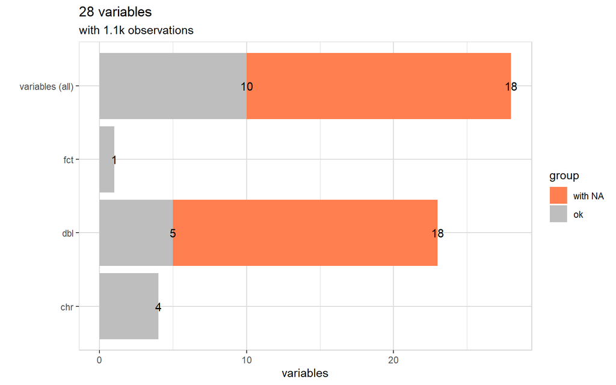

```r
explore_tbl(eu_data)
```

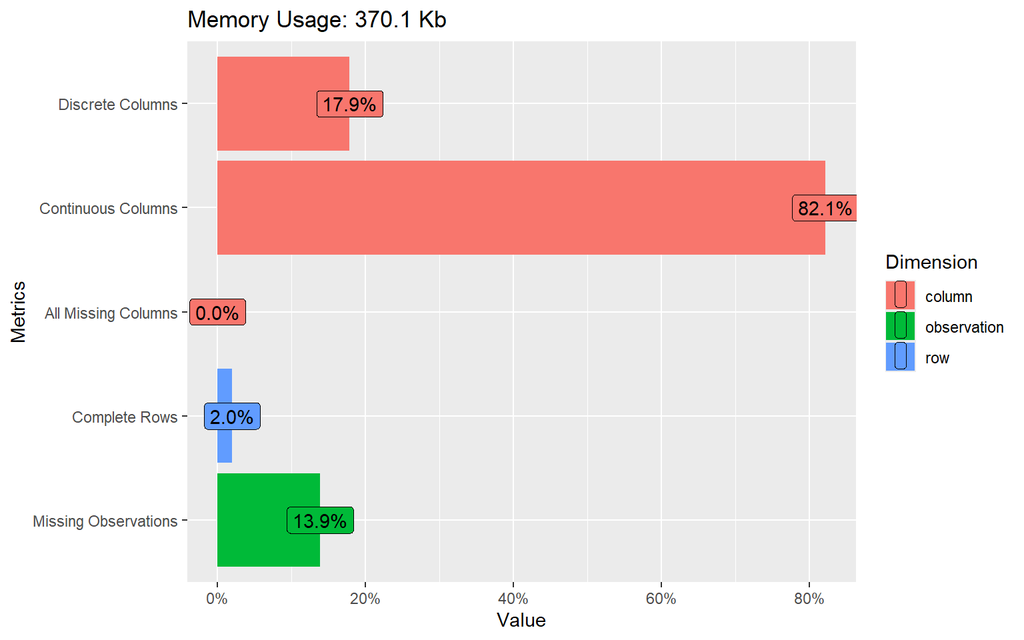

```r
plot_intro(eu_data)
```

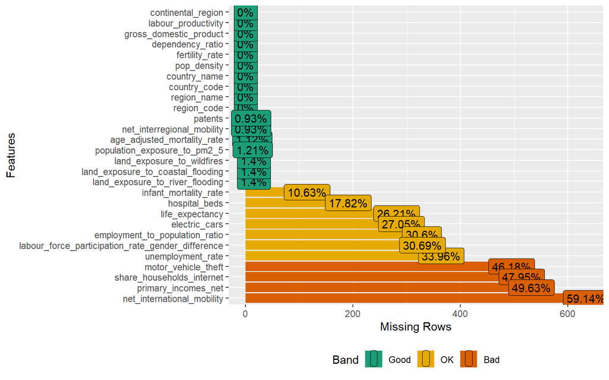

```r
plot_missing(eu_data)
```

There are some variables which have worrying numbers of missing values.

I am going to delete `net_international_mobility` because there is already a closely related (`net_interrregional_mobility`) with way less missing observations. I will also delete `primary_incomes_net` as that is likely to be related with GDP and `share_households_internet`. The rest of the missing values will be imputed.

```r
eu_data <- eu_data |>
  select(-c(net_international_mobility, primary_incomes_net, share_households_internet))
```

Checking if some countries have poor data quality by looking at the average number of NAs per observation in countries:

```r
eu_data |>
  mutate(na = rowSums(is.na(eu_data))) |>
  group_by(country_code) |>
  summarize(mean_na = round(mean(na, na.rm = TRUE), 2)) |>
  print(n=Inf)
```

```
## # A tibble: 22 × 2
##    country_code mean_na
##    <chr>          <dbl>
##  1 AUT             3
##  2 BEL             3.45
##  3 CZE             0
##  4 DEU             1
##  5 DNK             1.09
##  6 ESP             0.81
##  7 EST             1.2
##  8 FIN             5
##  9 FRA             3.01
## 10 GRC             7.1
## 11 HUN             0
## 12 IRL             2
## 13 ITA             1.28
## 14 LTU             1.2
## 15 LUX             9
## 16 LVA             0
## 17 NLD             8
## 18 POL             5.01
## 19 PRT             4.32
## 20 SVK             1
## 21 SVN             1
## 22 SWE             0
```

```r
summary(eu_data)
```

```
##  region_code        region_name        country_code       country_name
##  Length:1072        Length:1072        Length:1072        Length:1072
##  Class :character   Class :character   Class :character   Class :character
##  Mode  :character   Mode  :character   Mode  :character   Mode  :character
##
##
##
##
##   pop_density        age_adjusted_mortality_rate infant_mortality_rate
##  Min.   :    1.947   Min.   : 4.372              Min.   :0.595
##  1st Qu.:   71.684   1st Qu.: 6.626              1st Qu.:2.583
##  Median :  138.166   Median : 7.038              Median :3.167
##  Mean   :  436.580   Mean   : 7.420              Mean   :3.254
##  3rd Qu.:  334.381   3rd Qu.: 7.652              3rd Qu.:3.775
##  Max.   :21290.934   Max.   :13.419              Max.   :9.167
##                      NA's   :12                  NA's   :114
##  life_expectancy fertility_rate   dependency_ratio net_interregional_mobility
##  Min.   :71.83   Min.   :0.8722   Min.   : 4.97    Min.   :-5.92385
##  1st Qu.:80.15   1st Qu.:1.3744   1st Qu.:27.99    1st Qu.:-0.17461
##  Median :81.11   Median :1.5527   Median :31.95    Median : 0.04308
##  Mean   :80.88   Mean   :1.5368   Mean   :32.22    Mean   :-0.05735
##  3rd Qu.:82.10   3rd Qu.:1.6525   3rd Qu.:36.14    3rd Qu.: 0.22817
##  Max.   :84.20   Max.   :4.6067   Max.   :62.38    Max.   : 2.46000
##  NA's   :281                                       NA's   :10
##  motor_vehicle_theft electric_cars     gross_domestic_product
##  Min.   :  1.225     Min.   :0.00001   Min.   : 13404
##  1st Qu.: 26.538     1st Qu.:0.00077   1st Qu.: 33236
##  Median : 67.569     Median :0.00205   Median : 42047
##  Mean   : 94.631     Mean   :0.00267   Mean   : 45263
##  3rd Qu.:126.939     3rd Qu.:0.00420   3rd Qu.: 51655
##  Max.   :834.100     Max.   :0.05063   Max.   :227484
##  NA's   :495         NA's   :290
##  labour_productivity employment_to_population_ratio unemployment_rate
##  Min.   : 35978      Min.   :37.25                  Min.   : 1.567
##  1st Qu.: 77724      1st Qu.:65.23                  1st Qu.: 4.681
##  Median : 88302      Median :71.29                  Median : 6.878
##  Mean   : 87608      Mean   :69.55                  Mean   : 8.104
##  3rd Qu.: 97522      3rd Qu.:75.90                  3rd Qu.: 9.733
##  Max.   :254193      Max.   :98.14                  Max.   :32.083
##                      NA's   :328                    NA's   :364
```

[output cut: 17 more lines]

```
##  Min.   :0.000000           Min.   : 0.000   Min.   : 3.591
##  1st Qu.:0.000000           1st Qu.: 3.374   1st Qu.:10.836
##  Median :0.000833           Median : 4.873   Median :12.455
##  Mean   :0.096503           Mean   : 5.459   Mean   :13.200
##  3rd Qu.:0.024833           3rd Qu.: 6.788   3rd Qu.:14.477
##  Max.   :5.043750           Max.   :25.741   Max.   :33.491
##  NA's   :15                 NA's   :191      NA's   :13
##     patents        continental_region
##  Min.   :   0.93   Eastern :127
##  1st Qu.:  18.93   Northern: 80
##  Median :  63.41   Southern:243
##  Mean   : 117.78   Western :622
##  3rd Qu.: 143.55
##  Max.   :2014.39
##  NA's   :10
```

Distribution of numeric variables:

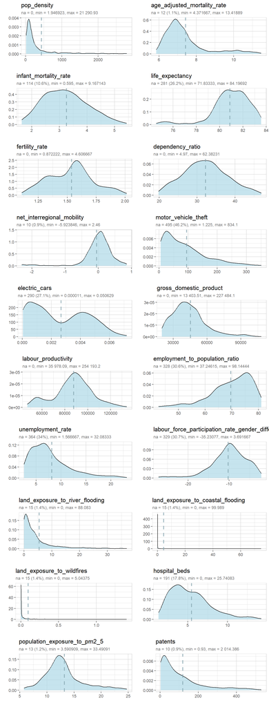

```r
explore_all(eu_data %>% select(where(is.numeric)))
```

Class distribution of the classification target variable:

```r
eu_data |>  count(continental_region)
```

```
## # A tibble: 4 × 2
##   continental_region     n
##   <fct>              <int>
## 1 Eastern              127
## 2 Northern              80
## 3 Southern             243
## 4 Western              622
```

The target variable for classification is not balanced, this can hinder the predictions, especially for the less represented levels.

Conditional boxplots of my predictors based on the classification target variable

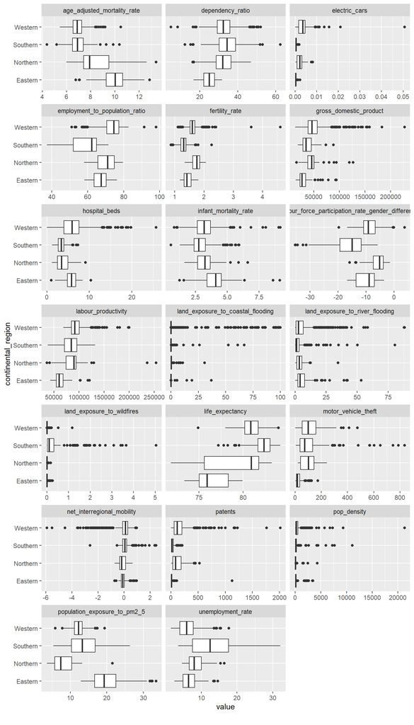

```r
plot_boxplot(eu_data, by="continental_region", ncol = 3, nrow = 7)
```

Correlation of numerical variables. Looking at `gross_domestic_product` I can also get an understanding of the most important predictors for what will be my target variable in the regression methods.

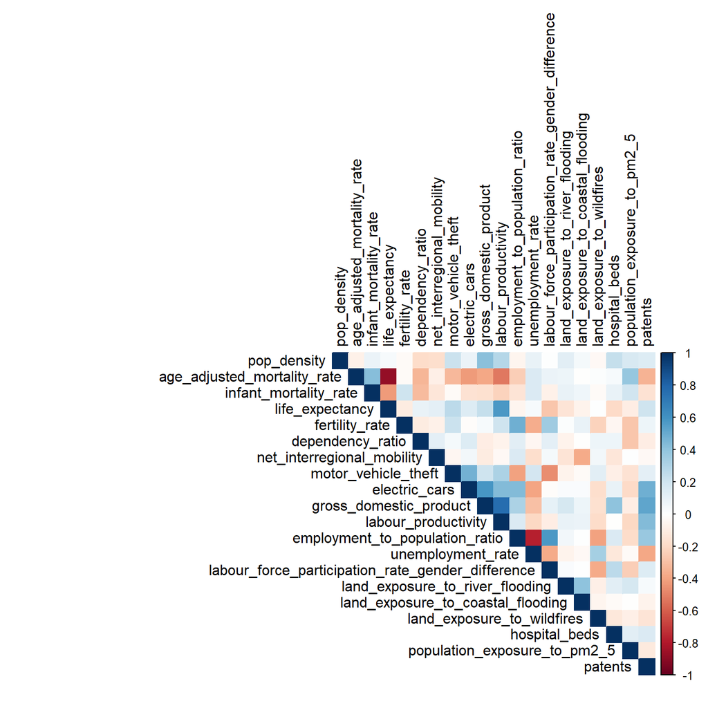

```r
cor <- cor(eu_data |>  select(where(is.numeric)), use = "pairwise.complete.obs")
corrplot::corrplot(cor, method = "color", type = "upper",
                   tl.col = "black",
                   is.corr = TRUE)
```

# Imputation of missing values

Since all of my data is numeric, I impute the rest of the missing data using `norm` method (i.e. bayesian linear regression). It would be better to impute several version of the dataset (`m>1`), run regression with all of them and the pool the results, but this is not the primary focus of the assignment so for simplicity and computational time reasons I impute the missing data just once.

```r
char_col <- eu_data |>
  select(c(region_code, region_name, country_code, country_name, continental_region))
num_col <- eu_data |>
  select(-c(region_code, region_name, country_code, country_name, continental_region))
imputed_df <- complete(mice(num_col, m=1, seed=123, printFlag=FALSE, method = "norm"))
imputed_df <- cbind(imputed_df, char_col)
```

We now have a complete dataset.

```r
describe_tbl(imputed_df)
```

```
## 1 072 (1.1k) observations with 25 variables
## 0 observations containing missings (NA)
## 0 variables containing missings (NA)
## 0 variables with no variance
```

# Classification

I try below several models. The sections will be usually structured like this:

1. First I train the models (using cross validation for hyperparameter tuning when the model has hyperparameters)
2. Then I use the models to predict the observations of the testing set and comment on the performance of the model
3. Finally I look at which variables are most important for each model, interpreting the results

## Preparation

First: dropping character variables

```r
imputed_df <- imputed_df |>
  select(-c(region_code, region_name, country_code, country_name))
```

Second: data splitting

70% of our observations will make up my training set, while the remaining 30% will be my testing set.

```r
set.seed(123)
in_train <- createDataPartition(imputed_df$continental_region, p = 0.7, list = FALSE)
training <- imputed_df[ in_train,]
testing <- imputed_df[-in_train,]
```

```r
nrow(training)
```

```
## [1] 752
```

```r
nrow(testing)
```

```
## [1] 320
```

Third: set the reference class as the one with most observations (Western Europe).

```r
training$continental_region <- relevel(training$continental_region, ref = "Western")
testing$continental_region <- relevel(testing$continental_region, ref = "Western")
```

## Setting the control function

3 fold cross validation is not ideal, but I need to set it this way due to computational times.

```r
ctrl <- trainControl(method = "cv",
                     number = 3,
                     classProbs = T,
                     summaryFunction = multiClassSummary,
                     returnResamp = "final",
                     savePredictions = "final",
                     verboseIter = F)
```

## Benchmark

First I run a benchmark model which predicts every observation the same (with the most common level for `continental_region`).

```r
benchmark_classification <- multinom(continental_region ~ 1,
                                     data = training,
                                     trace = FALSE)
predictions_benchmark <- predict(benchmark_classification,
                                 newdata=testing,
                                 type="class")
cm_benchmark_classification <- confusionMatrix(predictions_benchmark,
                                                testing$continental_region)
cm_benchmark_classification
```

```
## Confusion Matrix and Statistics
##
##           Reference
## Prediction Western Eastern Northern Southern
##   Western      186      38       24       72
##   Eastern        0       0        0        0
##   Northern       0       0        0        0
##   Southern       0       0        0        0
##
## Overall Statistics
##
##                Accuracy : 0.5812
##                  95% CI : (0.5251, 0.6359)
##     No Information Rate : 0.5812
##     P-Value [Acc > NIR] : 0.5238
##
##                   Kappa : 0
##
##  Mcnemar's Test P-Value : NA
##
## Statistics by Class:
##
##                      Class: Western Class: Eastern Class: Northern
## Sensitivity                  1.0000         0.0000           0.000
## Specificity                  0.0000         1.0000           1.000
## Pos Pred Value               0.5813            NaN             NaN
## Neg Pred Value                  NaN         0.8812           0.925
## Prevalence                   0.5813         0.1187           0.075
## Detection Rate               0.5813         0.0000           0.000
## Detection Prevalence         1.0000         0.0000           0.000
## Balanced Accuracy            0.5000         0.5000           0.500
##                      Class: Southern
## Sensitivity                    0.000
## Specificity                    1.000
## Pos Pred Value                   NaN
## Neg Pred Value                 0.775
## Prevalence                     0.225
## Detection Rate                 0.000
## Detection Prevalence           0.000
## Balanced Accuracy              0.500
```

As can be seen, even though all observations are assigned to the most common class this already yields a 58% accuracy. This is a remainder to always treat accuracy carefully.

## Multinomial logistic regression

I now run a simple multinomial logistic regression.

```r
training_scaled <- training |>
  mutate(across(where(is.numeric), scale))
testing_scaled <- testing |>
  mutate(across(where(is.numeric), scale))
multinomial_classification <- multinom(continental_region ~ .,
                                       data = training_scaled,
                                       trace=FALSE)
```

A multinomial logistic regression predicts the probability of an observation belonging to each of the possible categories. For every observation all the probabilities of all the classes of the factor are estimated. Then, unless prompt otherwise the model assigns the observation to the class with the highest probability.

```r
predictions_multinomial <- predict(multinomial_classification,
                                   newdata=testing_scaled,
                                   type="class")
cm_multinomial_classification <- confusionMatrix(predictions_multinomial,
                                                 testing_scaled$continental_region)
cm_multinomial_classification
```

```
## Confusion Matrix and Statistics
##
##           Reference
## Prediction Western Eastern Northern Southern
##   Western      181       0        3        5
##   Eastern        1      38        2        1
##   Northern       2       0       19        0
##   Southern       2       0        0       66
##
## Overall Statistics
##
##                Accuracy : 0.95
##                  95% CI : (0.9201, 0.9712)
##     No Information Rate : 0.5812
##     P-Value [Acc > NIR] : < 2.2e-16
##
##                   Kappa : 0.915
##
##  Mcnemar's Test P-Value : NA
##
## Statistics by Class:
##
##                      Class: Western Class: Eastern Class: Northern
## Sensitivity                  0.9731         1.0000         0.79167
## Specificity                  0.9403         0.9858         0.99324
## Pos Pred Value               0.9577         0.9048         0.90476
## Neg Pred Value               0.9618         1.0000         0.98328
## Prevalence                   0.5813         0.1187         0.07500
## Detection Rate               0.5656         0.1187         0.05937
## Detection Prevalence         0.5906         0.1313         0.06563
## Balanced Accuracy            0.9567         0.9929         0.89245
##                      Class: Southern
## Sensitivity                   0.9167
## Specificity                   0.9919
## Pos Pred Value                0.9706
## Neg Pred Value                0.9762
## Prevalence                    0.2250
## Detection Rate                0.2062
## Detection Prevalence          0.2125
## Balanced Accuracy             0.9543
```

```r
multinomial_classification$AIC
```

```
## [1] 246.6827
```

A simple multinomial logistic regression is already able to correctly classify around 95% of the observations as we see from the confusion matrix. Furthermore, the results seem robust, confirmed by a high Kappa, with a good equilibrium between sensitivity and specificity for all classes. The model only seems to have some difficulties for Northern Europe regions (the least represented class), often confusing them with Western Europe regions. This is understandable as these 2 subregions are probably fairly similar and with Northern Europe being the least represented class, the model might suffer from class imbalance and not learn accurately all the patterns for the scarcely represented classes.

Below I print only the coefficients that were found significant at a 1% level:

```r
tidy(multinomial_classification) |>
  filter(p.value < 0.01) |>
  rename(coefficient = estimate) |>
  mutate(exp_coefficient = exp(coefficient), .before=std.error)  |>
  select(-c(statistic, std.error)) |>
  mutate(across(where(is.numeric), ~ round(.x, 3)))
```

```
## # A tibble: 19 × 5
##    y.level  term                         coefficient exp_coefficient p.value
##    <chr>    <chr>                              <dbl>           <dbl>   <dbl>
##  1 Eastern  (Intercept)                        -8.78           0       0.002
##  2 Eastern  gross_domestic_product              6.16         471.      0.002
##  3 Eastern  labour_productivity                -8.84           0       0
##  4 Eastern  hospital_beds                      -3.85           0.021   0.002
##  5 Eastern  population_exposure_to_pm2_5        4.66         105.      0
##  6 Northern (Intercept)                       -12.7            0       0
##  7 Northern age_adjusted_mortality_rate        11.4        89813.      0
##  8 Northern fertility_rate                      3.44          31.3     0.005
##  9 Northern gross_domestic_product              4.71         111.      0.008
## 10 Northern labour_productivity                -5.14           0.006   0.003
## 11 Northern population_exposure_to_pm2_5       -5.93           0.003   0
## 12 Southern (Intercept)                        -3.64           0.026   0
## 13 Southern life_expectancy                     5.17         175.      0.001
## 14 Southern fertility_rate                     -3.35           0.035   0
## 15 Southern labour_productivity                -5.28           0.005   0
## 16 Southern land_exposure_to_wildfires          7.92        2766.      0.001
## 17 Southern hospital_beds                      -2.02           0.133   0.001
## 18 Southern population_exposure_to_pm2_5        3.22          24.9     0
## 19 Southern patents                            -6.23           0.002   0
```

The coefficients in the table above tell how each predictor variable influences the relative likelihood of being in a specific category (compared to the baseline category (i.e. Western Europe). For Eastern Europe, the biggest coefficient is `labour_productivity` with a negative sign indicating that as labour productivity increases, the log-odds of being in the Eastern region decrease and thus that Eastern Europe region tend to have lower `labour_productivity` than Western Europe’s regions. For Northern Europe, the biggest coefficient is `age_adjusted_mortality_rate` with a positive sign indicating that for each 1 standard deviation increase of `age_adjusted_mortality_rate` the log-odds of being a Northern country with respect to being a Western country increase by 11.4.

## LDA

```r
lda_classification <- lda(continental_region ~ ., data = training_scaled)
predictions_lda <- predict(lda_classification, newdata=testing_scaled)$class
cm_lda_classification <- confusionMatrix(predictions_lda,
                                         testing_scaled$continental_region)
cm_lda_classification
```

```
## Confusion Matrix and Statistics
##
##           Reference
## Prediction Western Eastern Northern Southern
##   Western      181       2        3        5
##   Eastern        0      36        2        2
##   Northern       3       0       19        1
##   Southern       2       0        0       64
##
## Overall Statistics
##
##                Accuracy : 0.9375
##                  95% CI : (0.9051, 0.9614)
##     No Information Rate : 0.5812
##     P-Value [Acc > NIR] : <2e-16
##
##                   Kappa : 0.8934
##
##  Mcnemar's Test P-Value : 0.2179
##
## Statistics by Class:
##
##                      Class: Western Class: Eastern Class: Northern
## Sensitivity                  0.9731         0.9474         0.79167
## Specificity                  0.9254         0.9858         0.98649
## Pos Pred Value               0.9476         0.9000         0.82609
## Neg Pred Value               0.9612         0.9929         0.98316
## Prevalence                   0.5813         0.1187         0.07500
## Detection Rate               0.5656         0.1125         0.05937
## Detection Prevalence         0.5969         0.1250         0.07187
## Balanced Accuracy            0.9492         0.9666         0.88908
##                      Class: Southern
## Sensitivity                   0.8889
## Specificity                   0.9919
## Pos Pred Value                0.9697
## Neg Pred Value                0.9685
## Prevalence                    0.2250
## Detection Rate                0.2000
## Detection Prevalence          0.2062
## Balanced Accuracy             0.9404
```

LDA yields only slightly worse results than multinomial classification without improving the previous model in any way.

## K Nearest Neighbor

Since we already have a really good model accuracy seems like a good metric to maximize, therefore from now on I will do hyperparameter tuning choosing as the best model the one that maximizes the accuracy.

Computational times do not allow to put very large grids for machine learning methods, however I have recursively defined several grids in each method before selecting the final most appropriate one in order to refine hyperparameters and improve predictions.

```r
param_grid = expand.grid(kmax = c(5, 10, 20), # Number of neighbors considered
                         distance = c(0.5, 0.7, 0.9), # Parameter of Minkowski distance
                         kernel = c("rectangular", "triangular")) # Kernel to use
set.seed(123)
knn_classification <- train(continental_region ~ .,
                            data = training,
                            method = "kknn",
                            tuneGrid = param_grid,
                            metric= "Accuracy",
                            trControl = ctrl,
                            preProcess = c("scale", "center"),
                            verbose = FALSE)
```

```r
knn_classification$bestTune
```

```
##    kmax distance      kernel
## 13   20      0.5 rectangular
```

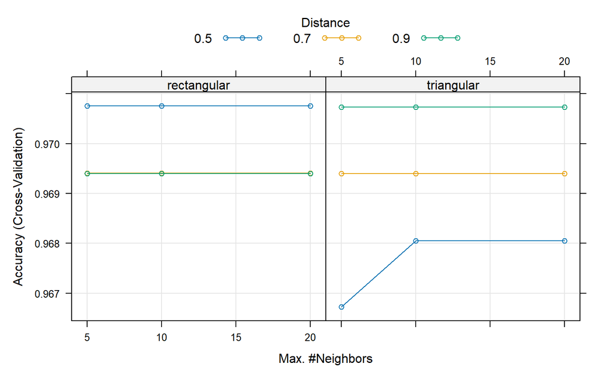

```r
plot(knn_classification)
```

```r
predictions_knn <- predict(knn_classification,
                           newdata=testing,
                           type="raw")
cm_knn_classification <- confusionMatrix(predictions_knn, testing$continental_region)
cm_knn_classification
```

```
## Confusion Matrix and Statistics
##
##           Reference
## Prediction Western Eastern Northern Southern
##   Western      185       0        2        2
##   Eastern        0      38        0        1
##   Northern       1       0       22        0
##   Southern       0       0        0       69
##
## Overall Statistics
##
##                Accuracy : 0.9812
##                  95% CI : (0.9596, 0.9931)
##     No Information Rate : 0.5812
##     P-Value [Acc > NIR] : < 2.2e-16
##
##                   Kappa : 0.9681
##
##  Mcnemar's Test P-Value : NA
##
## Statistics by Class:
##
##                      Class: Western Class: Eastern Class: Northern
## Sensitivity                  0.9946         1.0000         0.91667
## Specificity                  0.9701         0.9965         0.99662
## Pos Pred Value               0.9788         0.9744         0.95652
## Neg Pred Value               0.9924         1.0000         0.99327
## Prevalence                   0.5813         0.1187         0.07500
## Detection Rate               0.5781         0.1187         0.06875
## Detection Prevalence         0.5906         0.1219         0.07187
## Balanced Accuracy            0.9824         0.9982         0.95664
##                      Class: Southern
## Sensitivity                   0.9583
## Specificity                   1.0000
## Pos Pred Value                1.0000
## Neg Pred Value                0.9880
## Prevalence                    0.2250
## Detection Rate                0.2156
## Detection Prevalence          0.2156
## Balanced Accuracy             0.9792
```

KNN represents an improvement from previous models. Not only does the accuracy increase, but the model is also able to predict better Northern regions with a marked improvement of sensitivity for that class. In doing so also the Kappa (basically an accuracy score that also takes into account the possibility of being right by chance) increases. The good performance of KNN is also in line with it being an especially good model when having to classify geographic observations.

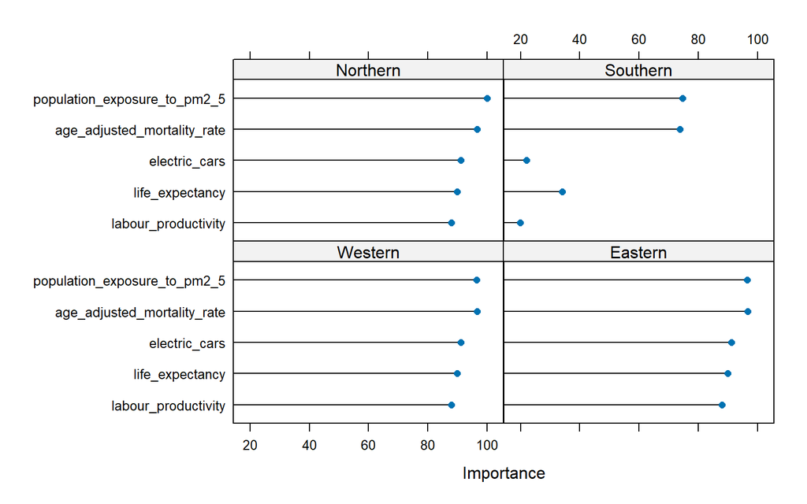

```r
knn_imp <- varImp(knn_classification)
plot(knn_imp, top=5)
```

In line with what seen before with the coefficient of the multinomial, also for KNN one of the most important variables seems to be `age_adjusted_mortality_rate`. `electric_cars` and `population_exposure_to_pm2_5` seem also important.

## Decision trees

```r
param_grid = expand.grid(cp = seq(0.05, 0.25, 0.02)) # Complexity Parameter
set.seed(123)
dt_classification <- train(continental_region ~ .,
                           data = training,
                           method = "rpart",
                           tuneGrid = param_grid,
                           metric= "Accuracy",
                           preProcess = c("scale", "center"),
                           trControl = ctrl)
```

The best hyperparameter was always the smallest here as it allows for more complexity. 0.05 allows for a nice visualization of a good number of nodes so I will stick to that.

```r
dt_classification$bestTune
```

```
##     cp
## 1 0.05
```

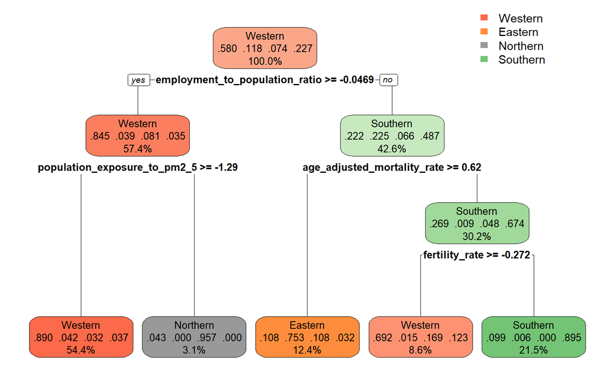

```r
rpart.plot(dt_classification$finalModel, digits=3)
```

The visualization of this decision tree allows me to identify patterns across regions. For example Southern Europe regions seem to have lower `employment_to_population_ratio`, lower `age_adjusted_mortality_rate` and lower `fertility_rate` than the rest of the subregions. Western Europe regions on the other hand seem to have higher `employment_to_population_ratio` and higher pollution (`population_exposure_tp_pm2_5`).

```r
predictions_dt <- predict(dt_classification,
                          newdata=testing,
                          type="raw")
cm_dt_classification <- confusionMatrix(predictions_dt, testing$continental_region)
cm_dt_classification
```

```
## Confusion Matrix and Statistics
##
##           Reference
## Prediction Western Eastern Northern Southern
##   Western      175      12        9        8
##   Eastern        3      26        3        7
##   Northern       0       0       12        0
##   Southern       8       0        0       57
##
## Overall Statistics
##
##                Accuracy : 0.8438
##                  95% CI : (0.7992, 0.8817)
##     No Information Rate : 0.5812
##     P-Value [Acc > NIR] : < 2.2e-16
##
##                   Kappa : 0.7242
##
##  Mcnemar's Test P-Value : NA
##
## Statistics by Class:
##
##                      Class: Western Class: Eastern Class: Northern
## Sensitivity                  0.9409        0.68421          0.5000
## Specificity                  0.7836        0.95390          1.0000
## Pos Pred Value               0.8578        0.66667          1.0000
## Neg Pred Value               0.9052        0.95730          0.9610
## Prevalence                   0.5813        0.11875          0.0750
## Detection Rate               0.5469        0.08125          0.0375
## Detection Prevalence         0.6375        0.12187          0.0375
## Balanced Accuracy            0.8622        0.81906          0.7500
##                      Class: Southern
## Sensitivity                   0.7917
## Specificity                   0.9677
## Pos Pred Value                0.8769
## Neg Pred Value                0.9412
## Prevalence                    0.2250
## Detection Rate                0.1781
## Detection Prevalence          0.2031
## Balanced Accuracy             0.8797
```

Because this is a single and simple tree results are a net worsening over KNN and even multinomial regression. Random forests and gradient boosting, by combining several trees should make for better predictions.

## Random Forest

```r
param_grid = expand.grid(predFixed = seq(5, 15, 5), # Number of Randomly Selected Predictors
                         minNode = seq(1, 10, 3)) # Minimal Node Size
set.seed(123)
rf_classification <- train(continental_region ~ .,
                           data = training,
                           method = "Rborist",
                           tuneGrid = param_grid,
                           metric= "Accuracy",
                           trControl = ctrl,
                           preProcess = c("scale", "center"),
                           verbose = FALSE)
```

```r
rf_classification$bestTune
```

```
##   predFixed minNode
## 6        10       4
```

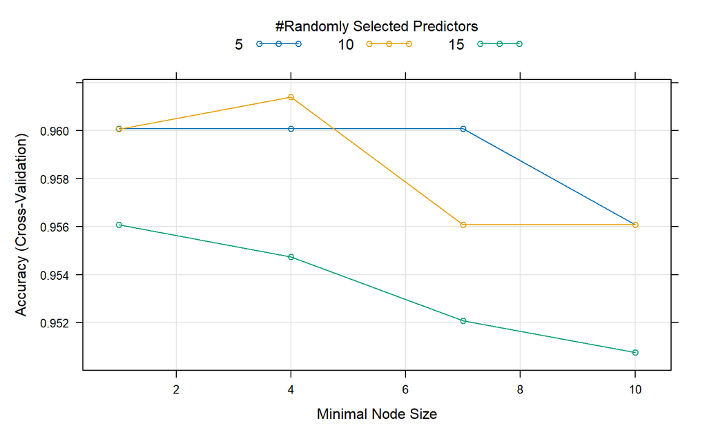

```r
plot(rf_classification)
```

```r
predictions_rf <- predict(rf_classification,
                          newdata=testing,
                          type="raw")
cm_rf_classification <- confusionMatrix(predictions_rf, testing$continental_region)
cm_rf_classification
```

```
## Confusion Matrix and Statistics
##
##           Reference
## Prediction Western Eastern Northern Southern
##   Western      184       1        5        2
##   Eastern        0      37        1        4
##   Northern       2       0       18        1
##   Southern       0       0        0       65
##
## Overall Statistics
##
##                Accuracy : 0.95
##                  95% CI : (0.9201, 0.9712)
##     No Information Rate : 0.5812
##     P-Value [Acc > NIR] : <2e-16
##
##                   Kappa : 0.9145
##
##  Mcnemar's Test P-Value : 0.1131
##
## Statistics by Class:
##
##                      Class: Western Class: Eastern Class: Northern
## Sensitivity                  0.9892         0.9737         0.75000
## Specificity                  0.9403         0.9823         0.98986
## Pos Pred Value               0.9583         0.8810         0.85714
## Neg Pred Value               0.9844         0.9964         0.97993
## Prevalence                   0.5813         0.1187         0.07500
## Detection Rate               0.5750         0.1156         0.05625
## Detection Prevalence         0.6000         0.1313         0.06563
## Balanced Accuracy            0.9648         0.9780         0.86993
##                      Class: Southern
## Sensitivity                   0.9028
## Specificity                   1.0000
## Pos Pred Value                1.0000
## Neg Pred Value                0.9725
## Prevalence                    0.2250
## Detection Rate                0.2031
## Detection Prevalence          0.2031
## Balanced Accuracy             0.9514
```

Random forests makes for a solid model, but like multinomial and unlike KNN it suffers in the underrepresented class (Northern Europe).

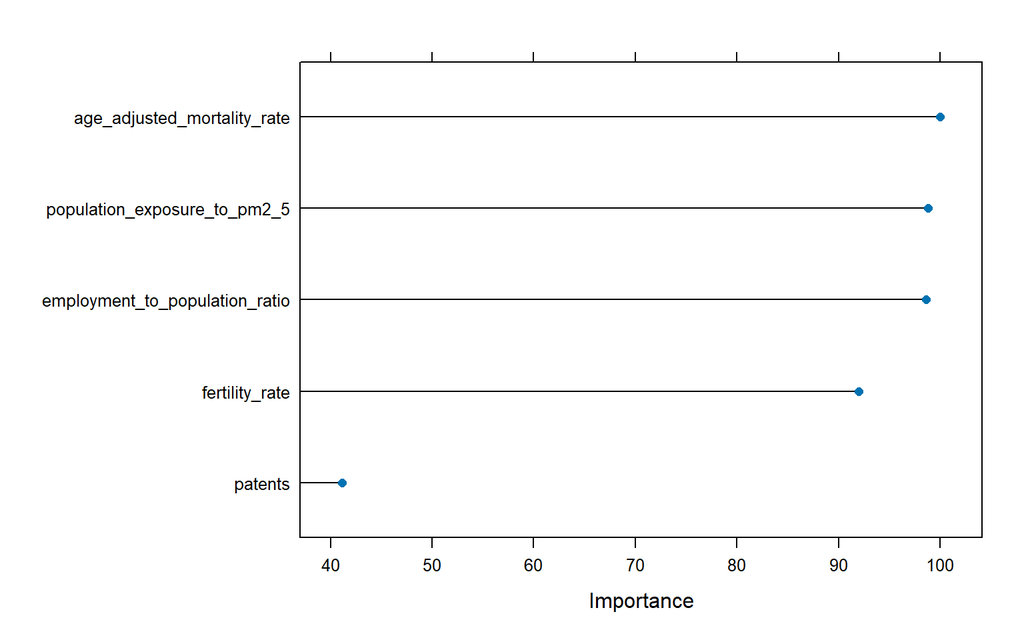

```r
rf_imp <- varImp(rf_classification)
plot(rf_imp, top = 5)
```

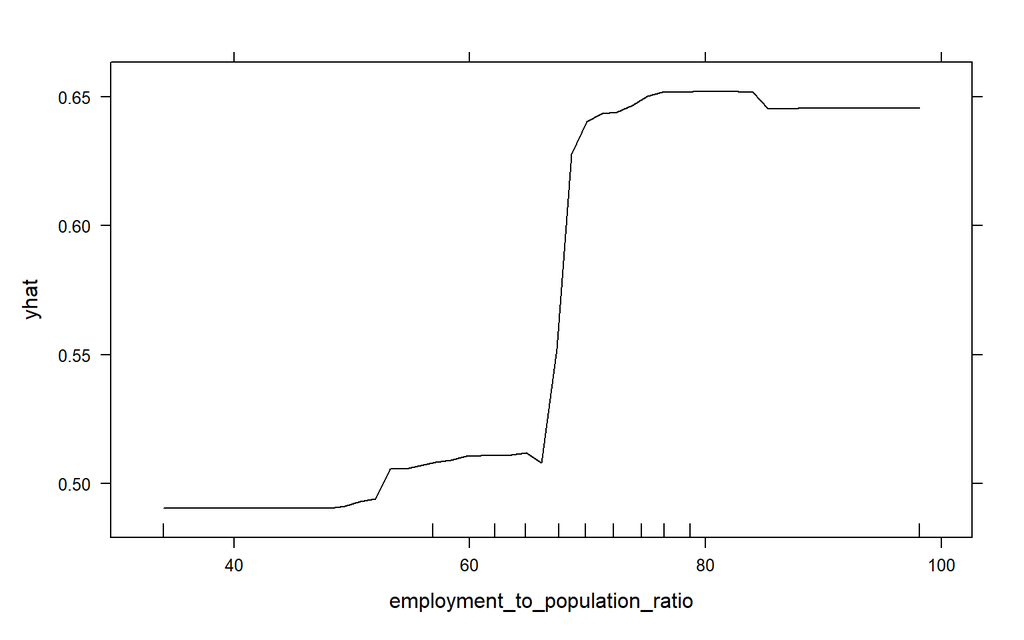

```r
partial(rf_classification, pred.var = "employment_to_population_ratio",
        which.class="Western",
        plot = TRUE, prob=TRUE, rug = TRUE)
```

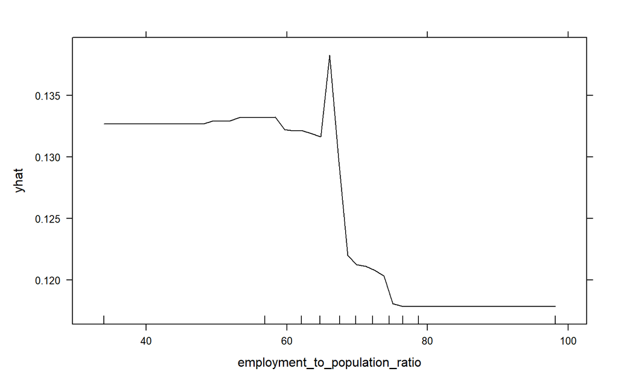

```r
partial(rf_classification, pred.var = "employment_to_population_ratio",
        which.class="Eastern",
        plot = TRUE, prob=TRUE, rug = TRUE)
```

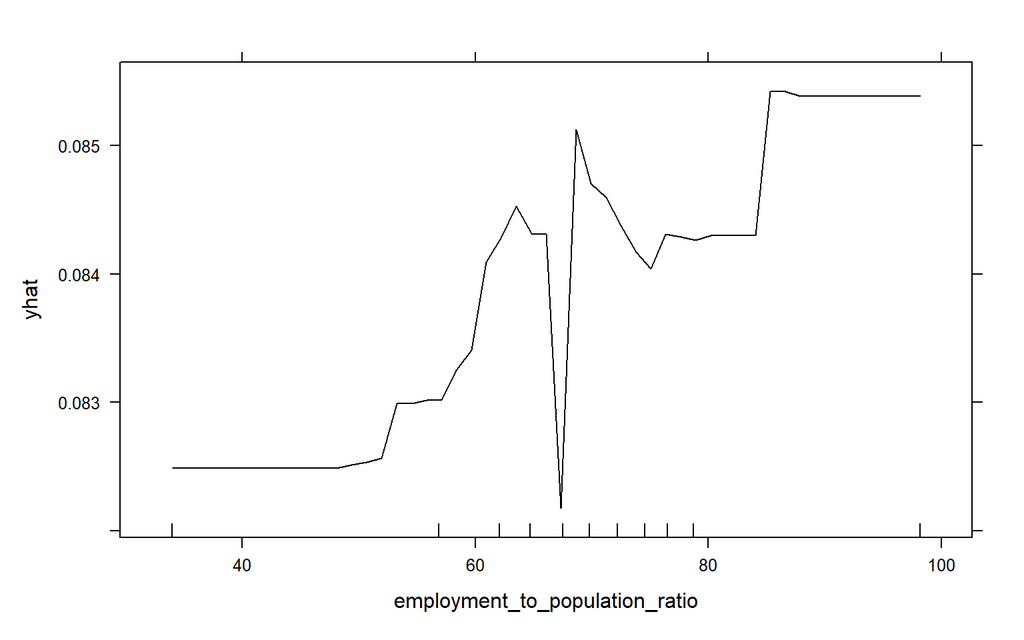

```r
partial(rf_classification, pred.var = "employment_to_population_ratio",
        which.class="Northern",
        plot = TRUE, prob=TRUE, rug = TRUE)
```

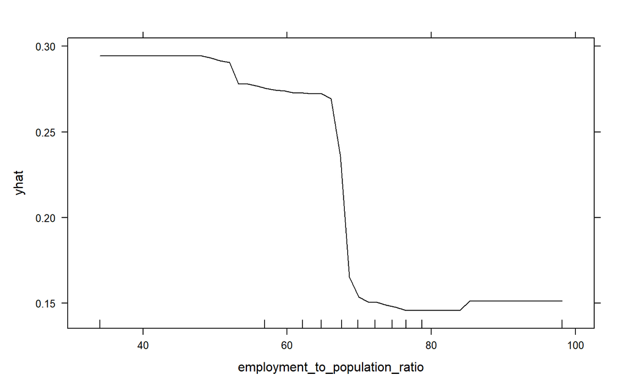

```r
partial(rf_classification, pred.var = "employment_to_population_ratio",
        which.class="Southern",
        plot = TRUE, prob=TRUE, rug = TRUE)
```

Similarly to KNN and the decision tree above `population_exposure_to_pm2_5`, `age_adjusted_mortality_rate`, `employment_to_population_ratio` seem to be the relevant variables to set apart EU’s regions

## Gradient Boosting

```r
param_grid = expand.grid(n.trees = c(200, 500), # Number of Boosting Iterations
                         interaction.depth = c(5, 10),  # Max Tree Depth
                         shrinkage = c(0.01, 0.1, 0.3), #Shrinkage
                         n.minobsinnode = c(10, 20, 30)) # Min. Terminal Node Size
set.seed(123)
gb_classification <- train(continental_region ~ .,
                           data = training,
                           method = "gbm",
                           tuneGrid = param_grid,
                           metric= "Accuracy",
                           trControl = ctrl,
                           preProcess = c("scale", "center"),
                           verbose = FALSE)
```

```r
gb_classification$bestTune
```

```
##    n.trees interaction.depth shrinkage n.minobsinnode
## 24     500                10       0.1             30
```

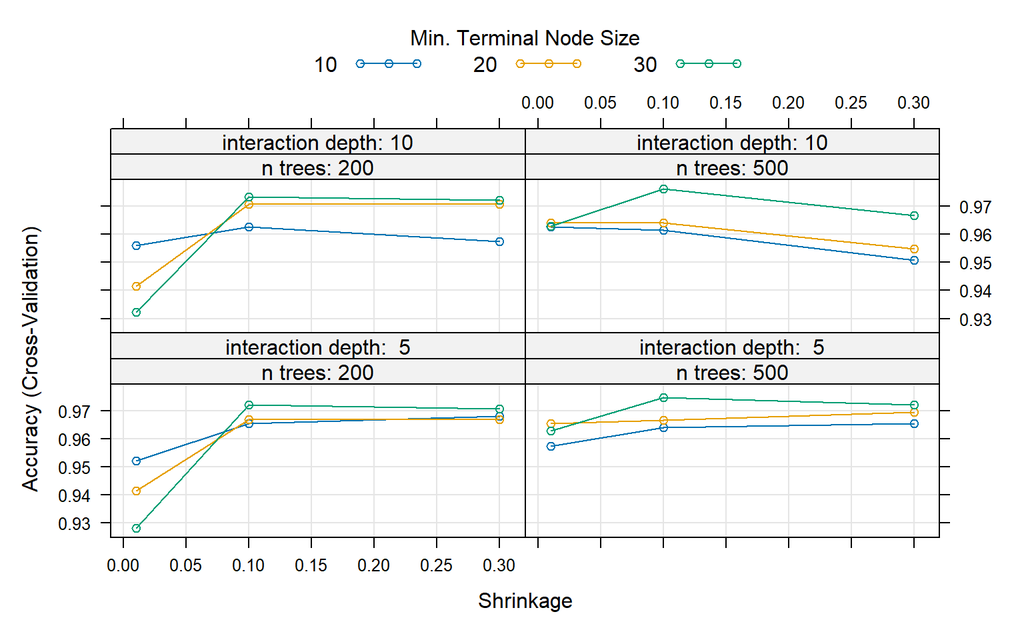

```r
plot(gb_classification)
```

```r
predictions_gb <- predict(gb_classification,
                          newdata=testing,
                          type="raw")
cm_gb_classification <- confusionMatrix(predictions_gb, testing$continental_region)
cm_gb_classification
```

```
## Confusion Matrix and Statistics
##
##           Reference
## Prediction Western Eastern Northern Southern
##   Western      185       1        2        2
##   Eastern        0      37        1        1
##   Northern       0       0       21        0
##   Southern       1       0        0       69
##
## Overall Statistics
##
##                Accuracy : 0.975
##                  95% CI : (0.9513, 0.9891)
##     No Information Rate : 0.5812
##     P-Value [Acc > NIR] : < 2.2e-16
##
##                   Kappa : 0.9574
##
##  Mcnemar's Test P-Value : NA
##
## Statistics by Class:
##
##                      Class: Western Class: Eastern Class: Northern
## Sensitivity                  0.9946         0.9737         0.87500
## Specificity                  0.9627         0.9929         1.00000
## Pos Pred Value               0.9737         0.9487         1.00000
## Neg Pred Value               0.9923         0.9964         0.98997
## Prevalence                   0.5813         0.1187         0.07500
## Detection Rate               0.5781         0.1156         0.06563
## Detection Prevalence         0.5938         0.1219         0.06563
## Balanced Accuracy            0.9787         0.9833         0.93750
##                      Class: Southern
## Sensitivity                   0.9583
## Specificity                   0.9960
## Pos Pred Value                0.9857
## Neg Pred Value                0.9880
## Prevalence                    0.2250
## Detection Rate                0.2156
## Detection Prevalence          0.2188
## Balanced Accuracy             0.9772
```

Gradient boosting performs only slightly worse than KNN, improving accuracy and sensitivity for Northern Europe regions with respect to random forests and multinomial logistic regression.

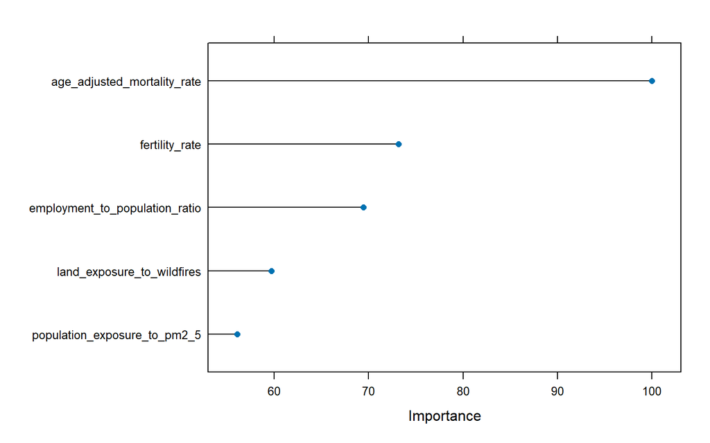

```r
gb_imp <- varImp(gb_classification)
plot(gb_imp, top = 5)
```

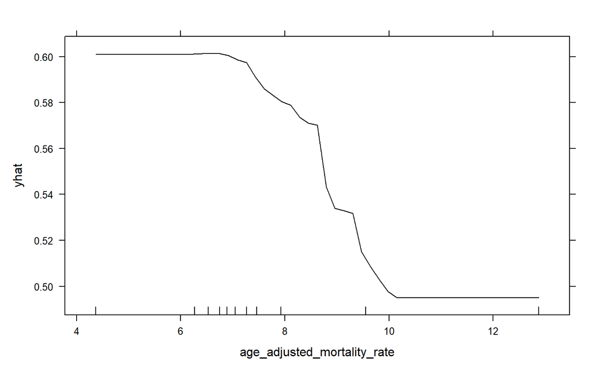

```r
partial(gb_classification, pred.var = "age_adjusted_mortality_rate",
        which.class="Western",
        plot = TRUE, prob=TRUE, rug = TRUE)
```

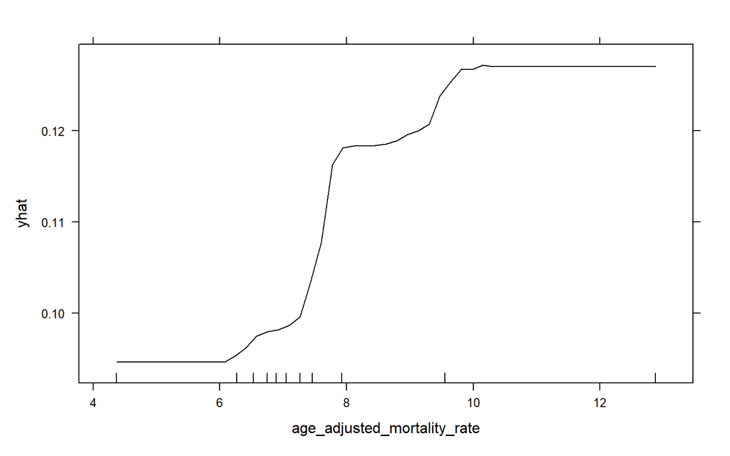

```r
partial(gb_classification, pred.var = "age_adjusted_mortality_rate",
        which.class="Eastern",
        plot = TRUE, prob=TRUE, rug = TRUE)
```

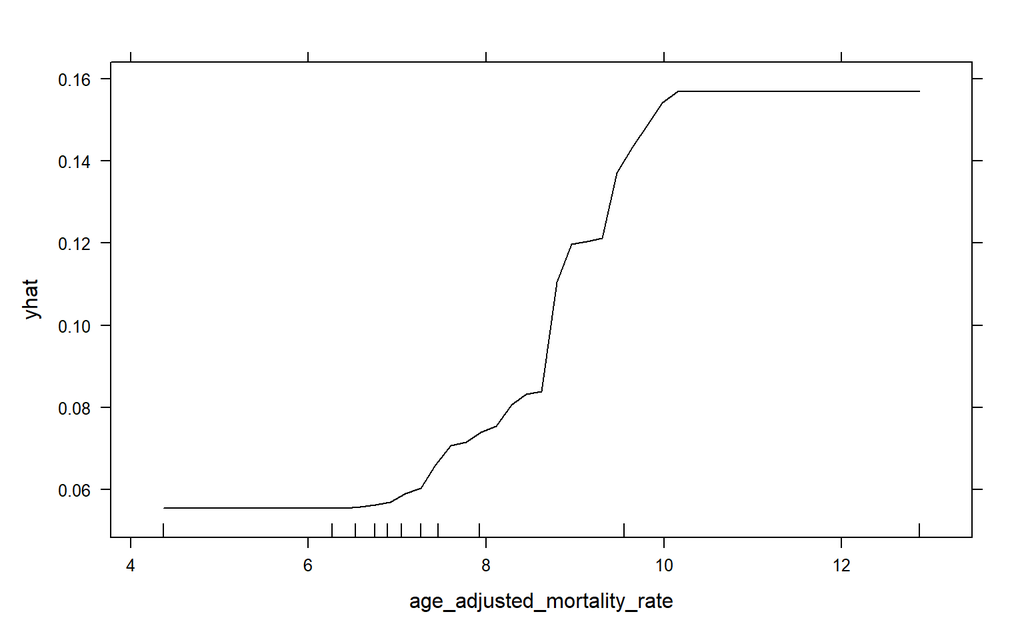

```r
partial(gb_classification, pred.var = "age_adjusted_mortality_rate",
        which.class="Northern",
        plot = TRUE, prob=TRUE, rug = TRUE)
```

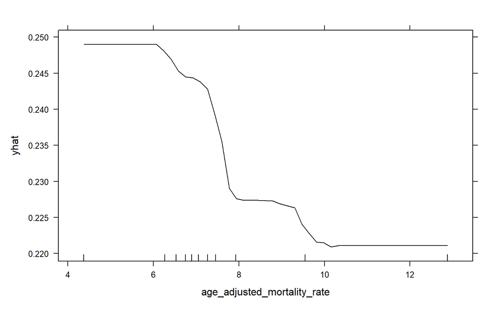

```r
partial(gb_classification, pred.var = "age_adjusted_mortality_rate",
        which.class="Southern",
        plot = TRUE, prob=TRUE, rug = TRUE)
```

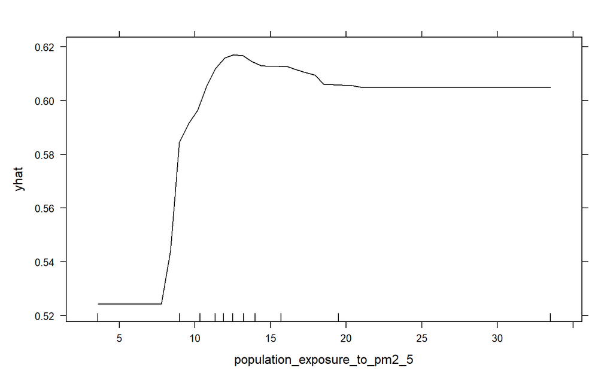

```r
partial(gb_classification, pred.var = "population_exposure_to_pm2_5",
        which.class="Western",
        plot = TRUE, prob=TRUE, rug = TRUE)
```

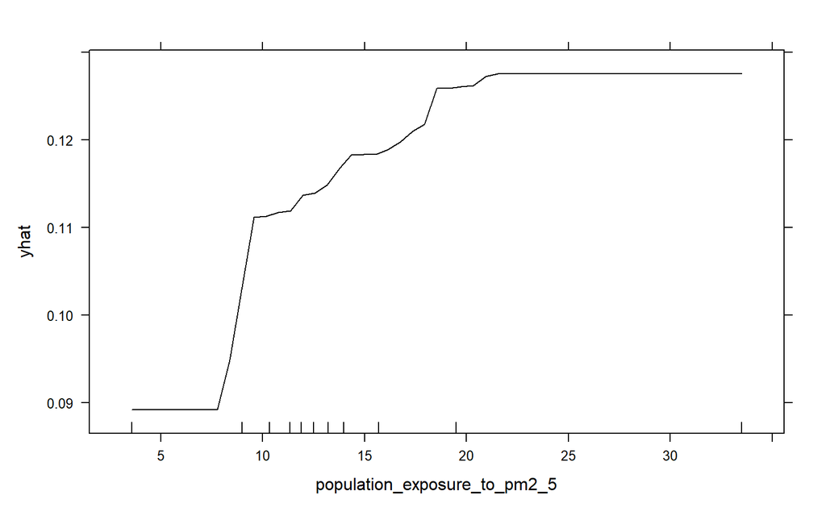

```r
partial(gb_classification, pred.var = "population_exposure_to_pm2_5",
        which.class="Eastern",
        plot = TRUE, prob=TRUE, rug = TRUE)
```

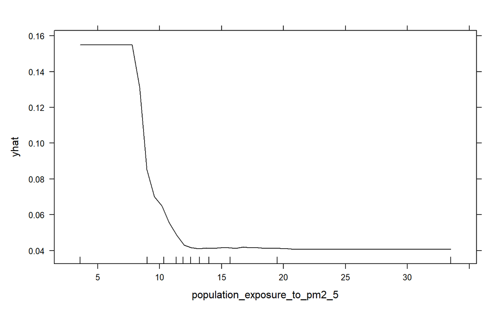

```r
partial(gb_classification, pred.var = "population_exposure_to_pm2_5",
        which.class="Northern",
        plot = TRUE, prob=TRUE, rug = TRUE)
```

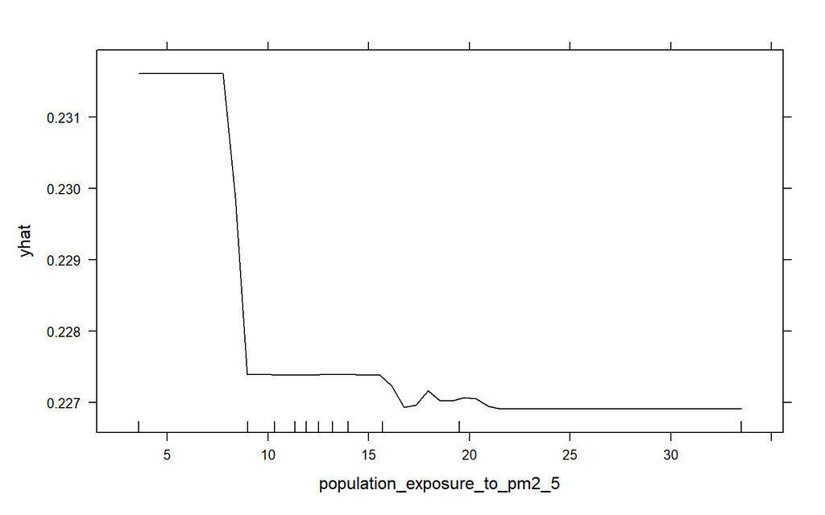

```r
partial(gb_classification, pred.var = "population_exposure_to_pm2_5",
        which.class="Southern",
        plot = TRUE, prob=TRUE, rug = TRUE)
```

A lot of emphasis seems to be put on `age_adjusted_mortality_rate` for gradient boosting. This and most of the remaining important variables are in line with the previous models.

Lower `age_adjusted_mortality_rate` seems to be associated with a higher likelihood of being either Southern Europe or Western Europe, while increases (within a certain range) of `age_adjusted_mortality_rate` seem to lead to an increase of likelihood of being a Eastern or Northern European region.

## Summary

```r
models_abbr <- c("benchmark", "multinomial", "lda", "knn", "dt", "rf", "gb")
models_name <- c("Benchmark", "Multinomial", "LDA", "KNN", "Decision Tree",
                "Random Forest", "Gradient Boosting")

# Create an empty tibble to store results
performance_results <- tibble()

# For loop to extract AIC, Accuracy, and Kappa for each model
for (i in 1:length(models_abbr)) {

  # Get the current model and its name
  model_abbr <- models_abbr[i]
  model_name <- models_name[i]

  # Get the confusion matrix for the model
  cm_name <- paste0("cm_", model_abbr, "_classification")
  cm <- get(cm_name)

  # Extract Accuracy and Kappa
  accuracy <- cm$overall["Accuracy"]
  kappa <- cm$overall["Kappa"]
  f1_scores <- cm$byClass[, 'F1']

  # Storing in a tibble all the F1 scores for all categories
  f1_df <- as_tibble_row(f1_scores) %>%
    rename_with(~ gsub("Class: ", "F1-", .))

  model_results <- tibble(Model = model_name,
                          Accuracy = accuracy,
                          Kappa = kappa) %>%
                          bind_cols(f1_df)

  # Store the results in the tibble
  performance_results <- bind_rows(performance_results,
                                   model_results)
}

performance_results
```

```
## # A tibble: 7 × 7
##   Model     Accuracy Kappa `F1-Western` `F1-Eastern` `F1-Northern` `F1-Southern`
##   <chr>        <dbl> <dbl>        <dbl>        <dbl>         <dbl>         <dbl>
## 1 Benchmark    0.581 0            0.735       NA            NA            NA
## 2 Multinom…    0.95  0.915        0.965        0.95          0.844         0.943
## 3 LDA          0.938 0.893        0.960        0.923         0.809         0.928
## 4 KNN          0.981 0.968        0.987        0.987         0.936         0.979
## 5 Decision…    0.844 0.724        0.897        0.675         0.667         0.832
## 6 Random F…    0.95  0.915        0.974        0.925         0.8           0.949
## 7 Gradient…    0.975 0.957        0.984        0.961         0.933         0.972
```

The best overall model for my classification task seems to be K-Nearest-Neighbor, followed closely by gradient boosting. Random forests, LDA and multinomial logistic regressions all provide really solid predictions, but tend to have more difficulties in the least represented class of Northern Europe.

The variables that allowed the models to tell the regions apart were almost always the same across all models with factors like lower employment to population ratio and lower age-adjusted mortality rate associated with Southern Europe, higher employment to population rate and less pollution for Northern Europe regions.

# Regression

The structure of the sections below will be similar to that adopted for the classification models.

When cross validation will be applied, the best model will be selected as the one that minimizes the Root Mean Squared Error.

## Preparation

I need to split the data one more time. Again 70% of our observations will make up my training set, while the remaining 30% will be my testing set.

```r
set.seed(123)
in_train <- createDataPartition(imputed_df$gross_domestic_product, p = 0.7, list = FALSE)
training <- imputed_df[ in_train,]
testing <- imputed_df[-in_train,]
```

```r
nrow(training)
```

```
## [1] 752
```

```r
nrow(testing)
```

```
## [1] 320
```

## Setting the control function

3 fold cross validation due to computational times.

```r
ctrl <- trainControl(method = "cv",
                     number = 3,
                     summaryFunction = defaultSummary,
                     returnResamp = "final",
                     savePredictions = "final",
                     verboseIter = F)
```

## Benchmark

Predicting every region with the mean GDP of all observations.

```r
benchmark_regression <- lm(gross_domestic_product ~ 1, data=training)
summary(benchmark_regression)
```

```
##
## Call:
## lm(formula = gross_domestic_product ~ 1, data = training)
##
## Residuals:
##    Min     1Q Median     3Q    Max
## -29505 -12018  -3207   6401 138340
##
## Coefficients:
##             Estimate Std. Error t value Pr(>|t|)
## (Intercept)  45253.4      727.7   62.18   <2e-16 ***
## ---
## Signif. codes:  0 '***' 0.001 '**' 0.01 '*' 0.05 '.' 0.1 ' ' 1
##
## Residual standard error: 19960 on 751 degrees of freedom
```

```r
predictions_benchmark <- predict(benchmark_regression,
                                 newdata=testing)
round(postResample(pred = predictions_benchmark,  obs = testing$gross_domestic_product),3)
```

```
##     RMSE Rsquared      MAE
## 20893.04       NA 13433.13
```

## Linear regression

```r
training_scaled <- training |>
  mutate(across(where(is.numeric), scale))
testing_scaled <- testing |>
  mutate(across(where(is.numeric), scale))
linear_regression <- lm(gross_domestic_product ~ ., data=training_scaled)
```

```r
tidy(linear_regression) |>
  select(-c(statistic, std.error)) |>
  mutate(across(where(is.numeric), ~ round(.x, 3))) %>%
  print(n = Inf)
```

```
## # A tibble: 23 × 3
##    term                                              estimate p.value
##    <chr>                                                <dbl>   <dbl>
##  1 (Intercept)                                          0.364   0
##  2 pop_density                                          0.126   0
##  3 age_adjusted_mortality_rate                         -0.252   0
##  4 infant_mortality_rate                               -0.042   0.034
##  5 life_expectancy                                     -0.293   0
##  6 fertility_rate                                      -0.158   0
##  7 dependency_ratio                                    -0.055   0.005
##  8 net_interregional_mobility                          -0.017   0.339
##  9 motor_vehicle_theft                                 -0.026   0.174
## 10 electric_cars                                        0.095   0
## 11 labour_productivity                                  0.795   0
## 12 employment_to_population_ratio                       0.145   0
## 13 unemployment_rate                                    0.014   0.651
## 14 labour_force_participation_rate_gender_difference   -0.044   0.058
## 15 land_exposure_to_river_flooding                      0.004   0.796
## 16 land_exposure_to_coastal_flooding                    0.039   0.036
## 17 land_exposure_to_wildfires                           0.029   0.124
## 18 hospital_beds                                        0.325   0
## 19 population_exposure_to_pm2_5                        -0.066   0.005
## 20 patents                                              0.105   0
## 21 continental_regionNorthern                          -0.013   0.902
## 22 continental_regionSouthern                          -0.329   0
## 23 continental_regionWestern                           -0.499   0
```

Most of the variables are significant. The most important (the one with the biggest coefficient) seems to be by far `labour_productivity`, with higher `labour_productivity` leading to higher `gross_domestic_product`.

```r
AIC(linear_regression)
```

```
## [1] 833.5076
```

```r
predictions_linear <- predict(linear_regression,
                              newdata=testing_scaled)
round(postResample(pred = predictions_linear,
                   obs = testing_scaled$gross_domestic_product),3)
```

```
##     RMSE Rsquared      MAE
##    0.399    0.843    0.296
```

A simple linear model is already able to explain 84% of the variability of my target variable. Note that for this model MAE and RMSE are scaled and need to be unscaled for proper interpretation.

## Stepwise feature selection

To make sure that I am not including too many features in my model I run a stepwise regression choosing the best model based on the AIC score.

```r
stepwise_regression <- ols_step_both_aic(linear_regression)
stepwise_regression
```

```
##
##
##                                                      Stepwise Summary
## ------------------------------------------------------------------------------------------------------------------------
## Step    Variable                                                   AIC         SBC         SBIC         R2       Adj. R2
## ------------------------------------------------------------------------------------------------------------------------
##  0      Base Model                                               2137.083    2146.328       -0.028    0.00000    0.00000
##  1      labour_productivity (+)                                  1479.679    1493.547     -657.441    0.58392    0.58336
##  2      hospital_beds (+)                                        1161.024    1179.515     -975.532    0.72836    0.72763
##  3      patents (+)                                              1075.352    1098.466    -1061.210    0.75825    0.75728
##  4      fertility_rate (+)                                       1036.114    1063.851    -1100.582    0.77115    0.76993
##  5      life_expectancy (+)                                       995.259    1027.618    -1141.367    0.78383    0.78238
##  6      electric_cars (+)                                         956.064     993.046    -1180.312    0.79535    0.79370
##  7      pop_density (+)                                           929.494     971.098    -1206.664    0.80298    0.80113
##  8      employment_to_population_ratio (+)                        904.651     950.878    -1231.177    0.80989    0.80784
##  9      continental_region (+)                                    883.038     943.133    -1256.295    0.81674    0.81402
##  10     age_adjusted_mortality_rate (+)                           854.510     919.228    -1284.085    0.82403    0.82118
##  11     population_exposure_to_pm2_5 (+)                          846.556     915.897    -1291.772    0.82635    0.82329
##  12     dependency_ratio (+)                                      840.162     914.126    -1297.897    0.82828    0.82501
##  13     land_exposure_to_coastal_flooding (+)                     834.080     912.666    -1303.675    0.83011    0.82665
##  14     infant_mortality_rate (+)                                 831.123     914.332    -1306.408    0.83123    0.82755
##  15     labour_force_participation_rate_gender_difference (+)     829.606     917.438    -1307.735    0.83201    0.82812
##  16     motor_vehicle_theft (+)                                   829.099     921.553    -1308.081    0.83257    0.82846
##  17     land_exposure_to_wildfires (+)                            828.706     925.783    -1308.303    0.83311    0.82877
## ------------------------------------------------------------------------------------------------------------------------
##
## Final Model Output
## ------------------
##
##                            Model Summary
## --------------------------------------------------------------------
## R                       0.913       RMSE                      0.408
## R-Squared               0.833       MSE                       0.167
## Adj. R-Squared          0.829       Coef. Var          1.202235e+18
## Pred R-Squared          0.818       AIC                     828.706
## MAE                     0.287       SBC                     925.783
## --------------------------------------------------------------------
##  RMSE: Root Mean Square Error
##  MSE: Mean Square Error
##  MAE: Mean Absolute Error
```

[output cut: 23 more lines]

```
##                                     electric_cars     0.092         0.019        0.092     4.853    0.000     0.055     0.129
##                                       pop_density     0.131         0.019        0.131     7.046    0.000     0.095     0.168
##                    employment_to_population_ratio     0.131         0.031        0.131     4.217    0.000     0.070     0.193
##                        continental_regionNorthern    -0.006         0.108       -0.002    -0.057    0.955    -0.217     0.205
##                        continental_regionSouthern    -0.323         0.092       -0.137    -3.498    0.000    -0.504    -0.142
##                         continental_regionWestern    -0.498         0.095       -0.247    -5.239    0.000    -0.685    -0.312
##                       age_adjusted_mortality_rate    -0.262         0.049       -0.262    -5.323    0.000    -0.358    -0.165
##                      population_exposure_to_pm2_5    -0.069         0.023       -0.069    -3.061    0.002    -0.114    -0.025
##                                  dependency_ratio    -0.055         0.019       -0.055    -2.822    0.005    -0.093    -0.017
##                 land_exposure_to_coastal_flooding     0.044         0.017        0.044     2.631    0.009     0.011     0.077
##                             infant_mortality_rate    -0.042         0.020       -0.042    -2.109    0.035    -0.081    -0.003
## labour_force_participation_rate_gender_difference    -0.046         0.023       -0.046    -1.961    0.050    -0.091     0.000
##                               motor_vehicle_theft    -0.030         0.019       -0.030    -1.560    0.119    -0.067     0.008
##                        land_exposure_to_wildfires     0.029         0.019        0.029     1.527    0.127    -0.008     0.066
## ------------------------------------------------------------------------------------------------------------------------------
```

I now repeat the same process using `caret::train`, but now focsuing on minimizing the RMSE.

```r
# Dummifying continental_region
training_dummies <- dummy_cols(training, select_columns = "continental_region",
                               remove_selected_columns = TRUE)
# Remove one of the dummy columns
training_dummies <- training_dummies[, !colnames(training_dummies) %in%
                                       c("continental_region_Western")]
# Same for testing
testing_dummies <- dummy_cols(testing, select_columns = "continental_region",
                              remove_selected_columns = TRUE)
testing_dummies <- testing_dummies[, !colnames(training_dummies) %in%
                                       c("continental_region_Western")]
param_grid = expand.grid(nvmax = seq(1, 20, 1)) # Maximum Number of Predictors
set.seed(123)
caret_sw_regression <- train(gross_domestic_product ~ .,
                            data = training_dummies,
                            method = "leapSeq",
                            tuneGrid = param_grid,
                            metric= "RMSE",
                            trControl = ctrl,
                            preProcess = c("scale", "center"),
                            verbose = FALSE)
```

```r
caret_sw_regression$bestTune
```

```
##    nvmax
## 17    17
```

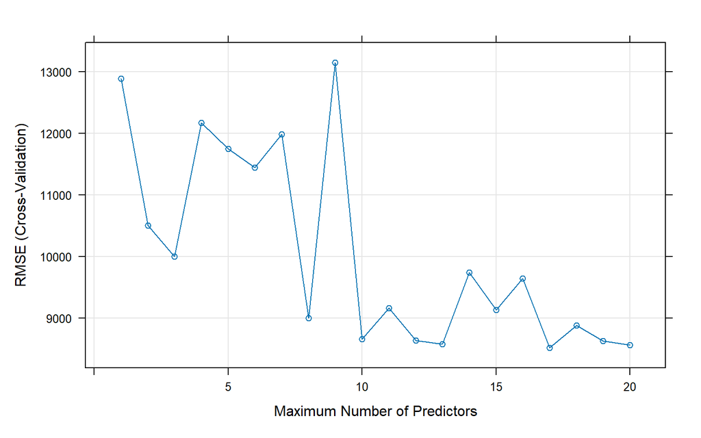

```r
plot(caret_sw_regression)
```

The best model is again one with 17 predictors.

```r
best_model_size <- caret_sw_regression$bestTune$nvmax
coef(caret_sw_regression$finalModel, id = best_model_size)
```

```
##                                       (Intercept)
##                                        45253.3891
##                                       pop_density
##                                         2488.5018
##                       age_adjusted_mortality_rate
##                                        -5236.4689
##                             infant_mortality_rate
##                                         -926.2923
##                                   life_expectancy
##                                        -6280.6281
##                                    fertility_rate
##                                        -3225.3197
##                                  dependency_ratio
##                                        -1138.7056
##                                     electric_cars
##                                         1886.1334
##                               labour_productivity
##                                        15862.9467
##                    employment_to_population_ratio
##                                         2453.8053
## labour_force_participation_rate_gender_difference
##                                         -804.5991
##                 land_exposure_to_coastal_flooding
##                                         1006.5301
##                                     hospital_beds
##                                         6485.2490
##                      population_exposure_to_pm2_5
##                                        -1555.1917
##                                           patents
##                                         2058.4301
##                        continental_region_Eastern
##                                         3179.1240
##                       continental_region_Northern
##                                         2546.0463
##                       continental_region_Southern
##                                         1588.6509
```

The predictors are almost exactly the same as for the stepwisie minimizing AIC.

```r
predictions_caret_sw <- predict(caret_sw_regression,
                                newdata=testing_dummies)
round(postResample(pred = predictions_caret_sw,
                   obs = testing_dummies$gross_domestic_product),3)
```

```
##     RMSE Rsquared      MAE
## 8146.177    0.849 5803.182
```

The R-squared is a slight improvement over the linear regression without any feature selection.

## Elastic-Net

I now apply shrinkage methods, in particular using cross validation for hyperparameter tuning of an elastic net model.

```r
param_grid = expand.grid(alpha = seq(0, 1, 0.1), # Mixing Percentage
                         lambda = seq(1, 100, 1)) # Regularization Parameter
set.seed(123)
elnet_regression <- train(gross_domestic_product ~ .,
                            data = training_dummies,
                            method = "glmnet",
                            tuneGrid = param_grid,
                            metric= "RMSE",
                            trControl = ctrl,
                            preProcess = c("scale", "center"),
                            verbose = FALSE)
```

```r
elnet_regression$bestTune
```

```
##      alpha lambda
## 1049     1     49
```

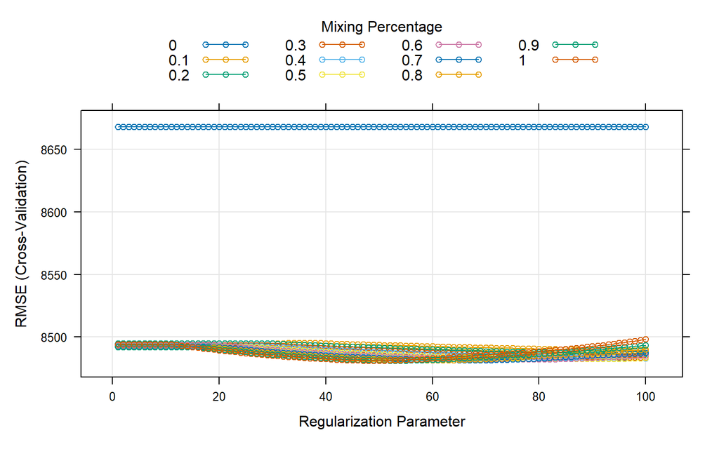

```r
plot(elnet_regression)
```

`alpha = 1` indicates that this is basically a Lasso regression.

```r
coef(elnet_regression$finalModel, s=elnet_regression$bestTune$lambda)
```

```
## 23 x 1 sparse Matrix of class "dgCMatrix"
##                                                           s1
## (Intercept)                                       45253.3891
## pop_density                                        2506.2765
## age_adjusted_mortality_rate                       -4007.4974
## infant_mortality_rate                              -703.2721
## life_expectancy                                   -4774.1989
## fertility_rate                                    -3287.3442
## dependency_ratio                                  -1048.3185
## net_interregional_mobility                         -343.8546
## motor_vehicle_theft                                -458.7266
## electric_cars                                      1911.9254
## labour_productivity                               15455.1852
## employment_to_population_ratio                     2723.5189
## unemployment_rate                                   136.9626
## labour_force_participation_rate_gender_difference  -745.3272
## land_exposure_to_river_flooding                     103.5254
## land_exposure_to_coastal_flooding                   732.6722
## land_exposure_to_wildfires                          542.6907
## hospital_beds                                      6361.6045
## population_exposure_to_pm2_5                      -1072.2706
## patents                                            2113.0905
## continental_region_Eastern                         2552.4288
## continental_region_Northern                        2379.4434
## continental_region_Southern                         990.0800
```

It seems like the model is actually not performing any kind of feature selection. It is keeping all the variables. The variables with the biggest coefficients are again `labour_productivity` and `hospital_beds`.

```r
predictions_elnet <- predict(elnet_regression,
                             newdata=testing_dummies)
round(postResample(pred = predictions_elnet,
                   obs = testing_dummies$gross_domestic_product),3)
```

```
##     RMSE Rsquared      MAE
## 8118.192    0.851 5770.069
```

The R-squared is another slight improvement over stepwise linera regression and simple linear regression. Also MAE and RMSE are lower for this ElasticNet model than for the stepwise model.

## K Nearest Neighbor

As many if not most of the variables seem relevant for the predictions I will keep using all of them also for the machine learning methods.

```r
param_grid = expand.grid(kmax = c(3, 5, 7, 9, 11), # Number of neighbors considered
                         distance = c(0.7, 0.9), # Parameter of Minkowski distance
                         kernel = c("rectangular", "triangular", "optimal")) # Kernel to use
set.seed(123)
knn_regression <- train(gross_domestic_product ~ .,
                            data = training,
                            method = "kknn",
                            tuneGrid = param_grid,
                            metric= "RMSE",
                            trControl = ctrl,
                            preProcess = c("scale", "center"),
                            verbose = FALSE)
```

```r
knn_regression$bestTune
```

```
##    kmax distance     kernel
## 29   11      0.9 triangular
```

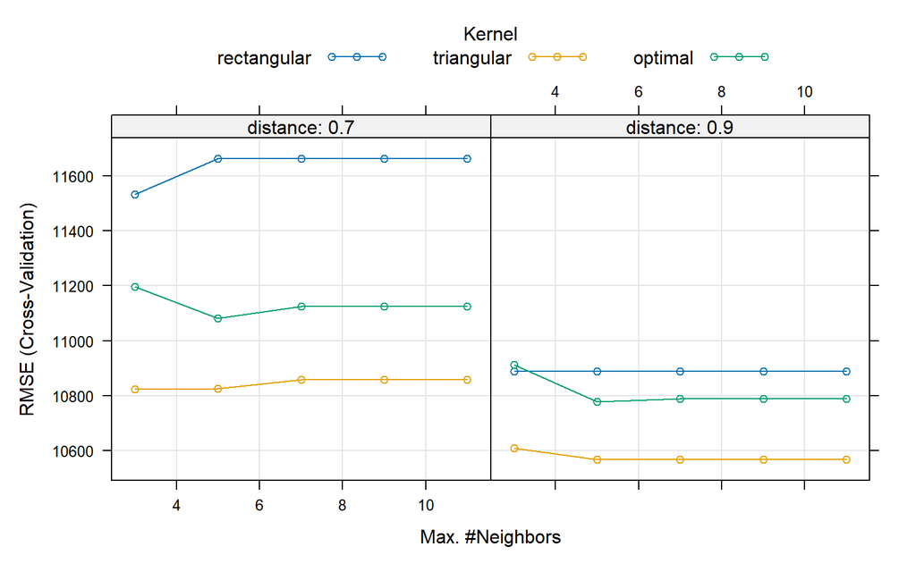

```r
plot(knn_regression)
```

```r
predictions_knn <- predict(knn_regression,
                           newdata=testing,
                           type="raw")
round(postResample(pred = predictions_knn,  obs = testing$gross_domestic_product),3)
```

```
##      RMSE  Rsquared       MAE
## 13862.056     0.579  6935.148
```

KNN does not seem a good choice for this prediction problem.

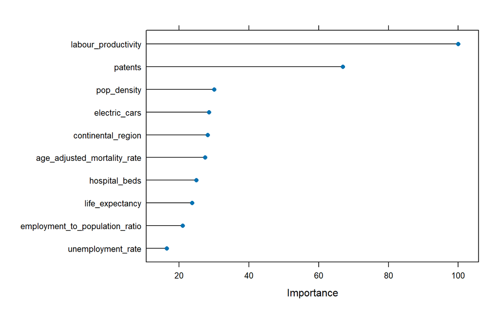

```r
knn_imp <- varImp(knn_regression)
plot(knn_imp, top=10)
```

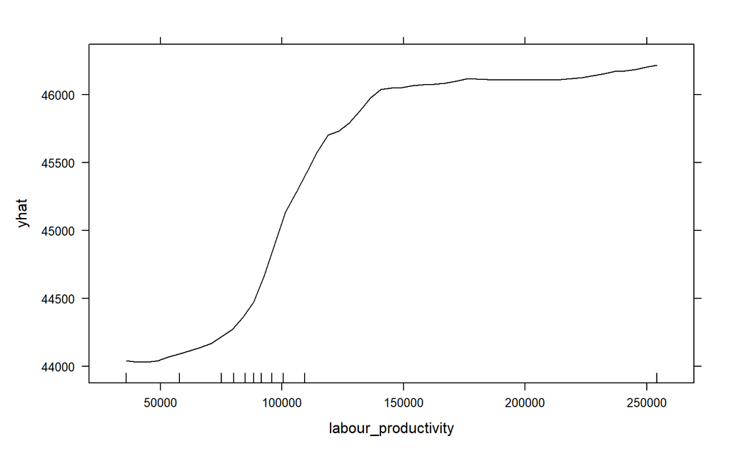

```r
partial(knn_regression, pred.var = "labour_productivity",
        plot = TRUE, rug = TRUE)
```

`labour_productivity` is again the top predictor. It seems to have mainly a positive linear relationship with `gross_domestic_product` as we would expect given the definition of the variable. This relationship seems to become less relevant and flat after a certain threshold.

## Decision trees

```r
param_grid = expand.grid(cp = seq(0.05, 0.25, 0.02)) # Complexity Parameter
set.seed(123)
dt_regression <- train(gross_domestic_product ~ .,
                           data = training,
                           method = "rpart",
                           tuneGrid = param_grid,
                           metric= "RMSE",
                           preProcess = c("scale", "center"),
                           trControl = ctrl)
```

The best hyperparameter was always the smallest here as it allows for more complexity. 0.05 however allows for a nice visualization of a good number of nodes so I will stick to that

```r
dt_regression$bestTune
```

```
##     cp
## 1 0.05
```

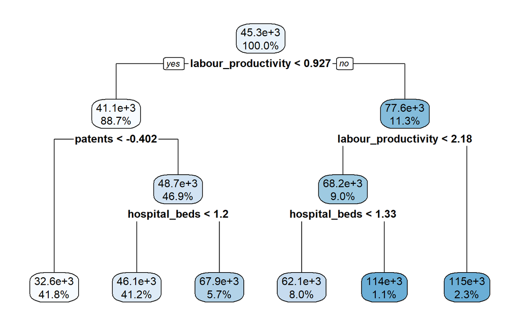

```r
rpart.plot(dt_regression$finalModel, digits=3)
```

All of the splits happen on either the variable `labour_productivity`, `patents` or `hospital_beds` further confirming that this are the three most important variables for our regression models part. Indeed `labour_productivity` has a direct relationship with GDP and `hospital_beds` and `patents` can be considered two good proxy for it as well.

```r
predictions_dt <- predict(dt_regression,
                           newdata=testing,
                           type="raw")
round(postResample(pred = predictions_dt,  obs = testing$gross_domestic_product),3)
```

```
##      RMSE  Rsquared       MAE
## 14252.966     0.541  9709.934
```

The predictive power of this model is low because it is made up of just one and simple decision tree. This predictive power should increase in random forests and gradient boosting.